# Trabajo MADII - Análisis multivariante de un conjunto de datos

Pablo Ascorbe Fernández e Ignacio Marco Pérez

2023-01-30

MADII - Análisis multivariante de un conjunto de datosEl objetivo de este documento es explicar paso por paso el código introducido en los scripts (homónimos al nombre que daremos a cada sección) que se encuentran en la carpeta `/Scripts` del proyecto, correspondientes a la cada una de las fases de estudio del dataset “good_reads_final”, disponible en el sitio web de [Kaggle](https://www.kaggle.com/code/jotamaggi/good-reads-author-gender-analysis).

El dataset en cuestión contiene información sobre un total de 22.891 libros de literatura extraídos de la página web [GoodReads](https://www.goodreads.com/), donde podemos encontrar los datos relativos a la identificación y detalles del autor y del libro, así como a las valoraciones de ambos. Este dataset nos ha resultado especialmente interesante, ya que, además de esta información, cada registro almacena el lugar de nacimiento y el género del autor, así como la fecha de publicación y los géneros principales del libro.

Una descripción detallada de cada variable podría ser la siguiente:

- `author_average_rating`: Valoración media (0-5) en las obras publicadas del autor en la página.
- `author_gender`: Género (`male` o `female`) del autor.
- `author_genres`: Géneros principales de las obras publicadas del autor en la página.
- `author_id`: Código identificador del autor en la página.
- `author_name`: Nombre completo del autor.
- `author_page_url`: Código URL de la página principal del autor.
- `author_rating_count`: Número total de valoraciones de las obras publicadas del autor en la página.
- `author_review_count`: Número de reseñas de las obras publicadas del autor en la página.
- `birthplace`: Lugar de nacimiento (ciudad, estado o país) del autor.
- `book_average_rating`: Valoración media (0-5) del libro en la página.
- `book_fullurl`: Código URL de la página del libro.
- `book_id`: Código identificador del libro en la página.
- `book_title`: Título del libro.
- `genre_1`: Género principal.
- `genre_2`: Género secundario más relevante.
- `num_ratings`: Número de valoraciones en la página.
- `num_reviews`: Número de reseñas en la página.
- `pages`: Número de páginas.
- `publish_date`: Fecha de publicación
- `score`: Información desconocida. Para el estudio, prescindiremos de esta variable.

De estas variables que hemos definido, realmente solo nos interesa trabajar con un subconjunto de ellas. Además, no todas están realmente estandarizadas (por ejemplo, las fechas de publicación no siguen un formato unificado). Por ello, uno de los primeros esfuerzos necesarios para llevar a cabo el estudio es el de preprocesar el dataset.

## 0. Preparación del proyecto

### 0.1. Creación de la estructura del proyecto

El primer paso para construir el proyecto es crear la estructura de este. Podemos utilizar el siguiente código (aunque la estructura ya está definida).

```r
if(!dir.exists("../Datos")){
  dir.create("../Datos")
}
if(!dir.exists("../Datos/Brutos")){
  dir.create("../Datos/Brutos")
}
if(!dir.exists("../Datos/Procesados")){
  dir.create("../Datos/Procesados")
}

if(!dir.exists("../Scripts")){
  dir.create("../Scripts")
}

if(!dir.exists("../Figuras")){
  dir.create("../Figuras")
}

if(!dir.exists("../Informes")){
  dir.create("../Informes")
}
```

### 0.2. Funciones auxiliares

Definamos las funciones auxiliares que emplearemos en fases posteriores del proyecto.

La función `asim` calcula el coeficiente de asimetría de un vector de valores (no nulos o nulos).

```r
asim <- function(x){
  x <- x[!is.na(x)]
  n <- length(x)
  return(mean((x - mean(x))^3)/(sd(x)^3))
}
```

La función `getYear` me permite obtener el año de un string que contenga el año como última subcadena tras un caracter `' '`.

```r
getYear <- function(dateString){
  return(unlist(strsplit(dateString, " "))[length(unlist(strsplit(dateString, " ")))] )
}
```

La función `mode` calcula la moda de un vector de valores (no nulos o nulos).

```r
mode <- function(x) {
  x <- x[!is.na(x)]
  return(names(which.max(table(x))))
}
```

La función `mcov` calcula la matriz de covarianzas de un dataframe `X` bajo la definición de covarianza estudiada en clase.

```r
mcov <- function(X){
  n <- dim(X)[1]
  return(cov(X)*(n - 1)/n)
}
```

### 0.3. Preprocesado de datos

Para llevar a cabo el preprocesado de los datos, extraeremos el DataFrame del archivo `good_reads_final.csv` que se encuentra en la carpeta `\Datos\Brutos`.

#### Importación y estudio inicial del DataFrame

Importamos el DataFrame.

```r
ruta_csv <- "../Datos/Brutos/good_reads_final.csv"
good_reads <- as.data.frame(read_csv(ruta_csv, col_names = TRUE))
```

Mostramos las columnas del DataFrame y vemos que coinciden con las definidas anteriormente.

```r
colnames(good_reads)
```

```
##  [1] "author_average_rating" "author_gender"         "author_genres"
##  [4] "author_id"             "author_name"           "author_page_url"
##  [7] "author_rating_count"   "author_review_count"   "birthplace"
## [10] "book_average_rating"   "book_fullurl"          "book_id"
## [13] "book_title"            "genre_1"               "genre_2"
## [16] "num_ratings"           "num_reviews"           "pages"
## [19] "publish_date"          "score"
```

Para poder hacernos una idea inicial de cómo son los datos, mostramos los primeros 5 registros

```r
head(good_reads, 5)
```

```
##   author_average_rating author_gender                         author_genres
## 1                  4.01        female                   historical-fiction,
## 2                  4.15          male literature-fiction,mystery-thrillers,
## 3                  4.00        female                              romance,
## 4                  3.88          male                       fiction,memoir,
## 5                  4.10        female                  young-adult,fantasy,
##   author_id           author_name                          author_page_url
## 1     74489   Victoria Thompson\n     /author/show/74489.Victoria_Thompson
## 2    706255       Stieg Larsson\n        /author/show/706255.Stieg_Larsson
## 3   5618190 Mimi Jean Pamfiloff\n /author/show/5618190.Mimi_Jean_Pamfiloff
## 4     37871         José Donoso\n            /author/show/37871.Jos_Donoso
## 5     36122   Patricia C. Wrede\n      /author/show/36122.Patricia_C_Wrede
##   author_rating_count author_review_count      birthplace book_average_rating
## 1               74399                6268 United States\n                4.02
## 2             3726435              142704        Sweden\n                4.13
```

[output cut: 21 more lines]

Ahora que hemos visto más o menos la forma de los datos, hagamos un pequeño resumen de las variables.

```r
summary(good_reads)
```

```
##  author_average_rating author_gender      author_genres        author_id
##  Min.   :1.82          Length:22891       Length:22891       Min.   :       4
##  1st Qu.:3.81          Class :character   Class :character   1st Qu.:   40836
##  Median :3.97          Mode  :character   Mode  :character   Median : 1415543
##  Mean   :3.96                                                Mean   : 3233957
##  3rd Qu.:4.12                                                3rd Qu.: 5775601
##  Max.   :5.00                                                Max.   :18770448
##
##  author_name        author_page_url    author_rating_count author_review_count
##  Length:22891       Length:22891       Min.   :       6    Min.   :     0
##  Class :character   Class :character   1st Qu.:    4324    1st Qu.:   545
##  Mode  :character   Mode  :character   Median :   24635    Median :  2273
##                                        Mean   :  172032    Mean   :  9370
##                                        3rd Qu.:  111337    3rd Qu.:  8262
##                                        Max.   :21117318    Max.   :516745
##
##   birthplace        book_average_rating book_fullurl         book_id
##  Length:22891       Min.   :0.000       Length:22891       Length:22891
##  Class :character   1st Qu.:3.770       Class :character   Class :character
##  Mode  :character   Median :3.960       Mode  :character   Mode  :character
##                     Mean   :3.951
##                     3rd Qu.:4.140
##                     Max.   :5.000
##
##   book_title          genre_1            genre_2           num_ratings
##  Length:22891       Length:22891       Length:22891       Min.   :      0
##  Class :character   Class :character   Class :character   1st Qu.:    820
##  Mode  :character   Mode  :character   Mode  :character   Median :   4403
##                                                           Mean   :  46683
##                                                           3rd Qu.:  20143
##                                                           Max.   :3820921
##
##   num_reviews         pages      publish_date           score
##  Min.   :     0   Min.   :   0   Length:22891       Min.   :    55
##  1st Qu.:   106   1st Qu.: 237   Class :character   1st Qu.:   832
##  Median :   384   Median : 315   Mode  :character   Median :  1727
##  Mean   :  2325   Mean   : 333                      Mean   :  3893
##  3rd Qu.:  1504   3rd Qu.: 384                      3rd Qu.:  3598
##  Max.   :147696   Max.   :6680                      Max.   :598270
##                   NA's   :3
```

Para ver un resumen más detallado utilizamos la función `describe`.

```r
describe(good_reads)
```

```
##                       vars     n       mean         sd     median    trimmed
## author_average_rating    1 22891       3.96       0.24       3.97       3.96
## author_gender*           2 22891       1.53       0.50       2.00       1.54
## author_genres*           3 22891    1029.96     528.92    1062.00    1050.01
## author_id                4 22891 3233956.76 3868090.63 1415543.00 2618586.34
## author_name*             5 22891    6052.66    3495.85    6031.00    6047.32
## author_page_url*         6 22891    5995.59    3476.42    5905.00    5980.94
## author_rating_count      7 22891  172031.92  654690.18   24635.00   59138.81
## author_review_count      8 22891    9369.80   24949.83    2273.00    4411.92
## birthplace*              9 22891     154.40     137.53     176.00     155.23
## book_average_rating     10 22891       3.95       0.29       3.96       3.96
## book_fullurl*           11 22891    8497.81    4919.10    8566.00    8518.77
## book_id*                12 22891    8497.81    4919.10    8566.00    8518.77
## book_title*             13 22891    8177.73    4710.70    8191.00    8180.61
## genre_1*                14 22891      70.13      32.86      73.00      70.22
## genre_2*                15 22891      86.96      44.03      80.00      86.67
## num_ratings             16 22891   46683.49  180069.81    4403.00   12281.12
## num_reviews             17 22891    2324.75    6837.50     384.00     854.91
## pages                   18 22888     333.00     219.33     315.00     313.77
## publish_date*           19 22610     821.64     853.03     313.00     644.73
## score                   20 22891    3893.03   11022.02    1727.00    2271.10
##                              mad   min      max       range  skew kurtosis
## author_average_rating       0.22  1.82        5        3.18 -0.21     1.58
## author_gender*              0.00  1.00        2        1.00 -0.13    -1.98
## author_genres*            639.00  1.00     1803     1802.00 -0.22    -1.25
## author_id             2094460.12  4.00 18770448 18770444.00  1.42     2.07
## author_name*             4468.56  1.00    12156    12155.00  0.01    -1.19
## author_page_url*         4370.70  1.00    12156    12155.00  0.04    -1.16
## author_rating_count     35337.77  6.00 21117318 21117312.00 14.72   346.94
## author_review_count      3092.70  0.00   516745   516745.00  8.77   116.15
## birthplace*               185.32  1.00      311      310.00 -0.06    -1.85
## book_average_rating         0.28  0.00        5        5.00 -0.34     2.59
## book_fullurl*            6410.76  1.00    16830    16829.00 -0.03    -1.23
## book_id*                 6410.76  1.00    16830    16829.00 -0.03    -1.23
## book_title*              6023.80  1.00    16350    16349.00 -0.01    -1.20
## genre_1*                   41.51  1.00      124      123.00  0.05    -1.07
## genre_2*                   66.72  1.00      157      156.00  0.04    -1.26
## num_ratings              6231.37  0.00  3820921  3820921.00  9.51   123.19
## num_reviews               508.53  0.00   147696   147696.00  7.44    79.61
## pages                     111.19  0.00     6680     6680.00  9.52   187.44
```

[output cut: 8 more lines]

```
## author_page_url*         22.98
## author_rating_count    4327.16
## author_review_count     164.91
## birthplace*               0.91
## book_average_rating       0.00
## book_fullurl*            32.51
## book_id*                 32.51
## book_title*              31.14
## genre_1*                  0.22
## genre_2*                  0.29
## num_ratings            1190.17
## num_reviews              45.19
## pages                     1.45
## publish_date*             5.67
## score                    72.85
```

Las columnas que realmente nos interesan para el estudio son las siguientes:

- `author_average_rating`
- `author_gender`
- `author_genres`
- `author_rating_count`
- `author_review_count`
- `birthplace`
- `book_average_rating`
- `genre_1`
- `genre_2`
- `num_ratings`
- `num_reviews`
- `pages`
- `publish_date`

De modo que eliminamos las variables irrelevantes.

```r
good_reads <- select(good_reads,-'author_id',-'author_name',-'author_page_url',
                     -'book_fullurl',-'book_id',-'book_title')

colnames(good_reads)
```

```
##  [1] "author_average_rating" "author_gender"         "author_genres"
##  [4] "author_rating_count"   "author_review_count"   "birthplace"
##  [7] "book_average_rating"   "genre_1"               "genre_2"
## [10] "num_ratings"           "num_reviews"           "pages"
## [13] "publish_date"          "score"
```

Para poder trabajar cómodamente con las columnas numéricas y categóricas, anotamos en dos vectores aquellas que corresponde con una categoría u otra.

```r
variables_categoricas <- c("author_gender",
                           "author_genres",
                           "birthplace",
                           "genre_1",
                           "genre_2")
variables_numericas <- c("author_average_rating",
                         "author_rating_count",
                         "author_review_count",
                         "book_average_rating",
                         "num_ratings",
                         "num_reviews",
                         "pages",
                         "publish_date")
```

#### Estudio de las variables categóricas del DataFrame

Para poder visualizar mejor los datos, mostramos los posibles valores que toma cada variable en el dataset.

```r
unique(good_reads$author_gender)
```

```
## [1] "female" "male"
```

```r
unique(good_reads$author_genres)[0:10]
```

```
##  [1] "historical-fiction,"
##  [2] "literature-fiction,mystery-thrillers,"
##  [3] "romance,"
##  [4] "fiction,memoir,"
##  [5] "young-adult,fantasy,"
##  [6] "horror,"
##  [7] "nonfiction,"
##  [8] "fantasy,"
##  [9] "young-adult,"
## [10] "science-fiction-fantasy,"
```

```r
unique(good_reads$birthplace)[0:10]
```

```
##  [1] "United States\n"       "Sweden\n"              "Chile\n"
##  [4] "\n"                    "\n  Canada\n"          "United Kingdom\n"
##  [7] "\n   United States\n"  "\n  Belgium\n"         "\n   United Kingdom\n"
## [10] "Cuba\n"
```

```r
unique(good_reads$genre_1)[0:10]
```

```
##  [1] "Mystery"         "Fiction"         "Romance"         "Fantasy"
##  [5] "Sequential Art"  "Young Adult"     "Nonfiction"      "Paranormal"
##  [9] "Historical"      "Science Fiction"
```

```r
unique(good_reads$genre_2)[0:10]
```

```
##  [1] "Historical"      "Mystery"         "Contemporary"    "Magical Realism"
##  [5] "Young Adult"     "Sequential Art"  "Romance"         "Science"
##  [9] "Horror"          "Fantasy"
```

Vemos que las dos variables que necesitan preprocesado son `author_genres` y `birthplace`.

Para tratar `author_genres`, convertimos el string segmentado por el caracter ‘,’ en un vector de componentes (géneros del autor).

```r
good_reads$author_genres <- strsplit(as.character(good_reads$author_genres), ",")
unique(good_reads$author_genres)[1:10]
```

```
## [[1]]
## [1] "historical-fiction"
##
## [[2]]
## [1] "literature-fiction" "mystery-thrillers"
##
## [[3]]
## [1] "romance"
##
## [[4]]
## [1] "fiction" "memoir"
##
## [[5]]
## [1] "young-adult" "fantasy"
##
## [[6]]
## [1] "horror"
##
## [[7]]
## [1] "nonfiction"
##
## [[8]]
## [1] "fantasy"
##
## [[9]]
## [1] "young-adult"
##
## [[10]]
## [1] "science-fiction-fantasy"
```

```r
good_reads[970,"author_genres"]
```

```
## [[1]]
## [1] "nonfiction"       "entertainment"    "gonzo-journalism"
```

Ahora, para tratar `birthplace`, debemos eliminar los caracteres indeseables de los datos.

```r
good_reads$birthplace <- gsub("\n   ", "", good_reads$birthplace)
good_reads$birthplace <- gsub("\n  ", "", good_reads$birthplace)
good_reads$birthplace <- gsub("[\n\r]", "", good_reads$birthplace)
unique(good_reads$birthplace)[1:10]
```

```
##  [1] "United States"  "Sweden"         "Chile"          ""
##  [5] "Canada"         "United Kingdom" "Belgium"        "Cuba"
##  [9] "Australia"      "New Zealand"
```

Todavía vemos valores anómalos, así que los sustituimos por valores nulos.

```r
good_reads$birthplace[good_reads$birthplace == ""] <- NA
good_reads$birthplace[good_reads$birthplace == "Occupied"] <- NA
good_reads$birthplace[good_reads$birthplace == "Republic of"] <- NA
good_reads$birthplace[good_reads$birthplace == "Identity of author to remamystery for now"] <- NA
good_reads$birthplace[good_reads$birthplace == "I've continued \"worlding\" to many countries."] <- NA
```

Ahora, homogeneizamos el dataset quedándonos únicamente con el país (convirtiendo aquellos datos que contengan información sobre ciudades, regiones, estados, etc.).

```r
good_reads$birthplace[good_reads$birthplace == "Seoul"] <- "South Korea"

good_reads$birthplace[good_reads$birthplace == "British India" |
                        good_reads$birthplace == "ndia"] <- "India"

good_reads$birthplace[good_reads$birthplace == "Hong Kong"] <- "China"

good_reads$birthplace[good_reads$birthplace == "Cape Town"] <- "South Africa"

good_reads$birthplace[good_reads$birthplace == "Melbourne"] <- "Australia"

good_reads$birthplace[good_reads$birthplace == "Jerusalem"] <- "Israel"

good_reads$birthplace[good_reads$birthplace == "the Former Yugoslav Republic of"] <- "Yugoslav Republic"

good_reads$birthplace[good_reads$birthplace == "Holy See (vatican City State)"] <- "Vatican City State"

good_reads$birthplace[good_reads$birthplace == "Winnipeg" |
                      good_reads$birthplace == "currently living Canada" |
                        good_reads$birthplace == "MB  Canada" |
                        good_reads$birthplace == "Vancouver" |
                        good_reads$birthplace == "Canada "] <- "Canada"

good_reads$birthplace[good_reads$birthplace == "Birmingham" |
                        good_reads$birthplace == "London" |
                        good_reads$birthplace == "British Indian Ocean Territory" |
                        good_reads$birthplace == "Gibraltar" |
                        good_reads$birthplace == "Buckinghamshire" |
                        good_reads$birthplace == "North Wales" |
                        good_reads$birthplace == "Westminister CA" |
                        good_reads$birthplace == "Northern Ireland" |
                        good_reads$birthplace == "British" |
                        good_reads$birthplace == "Lancashire" |
                        good_reads$birthplace == "Scotland" |
                        good_reads$birthplace == "Wales"] <- "United Kingdom"

good_reads$birthplace[good_reads$birthplace == "Colorado" |
                        good_reads$birthplace == "Chicago" |
                        good_reads$birthplace == "Alabama" |
                        good_reads$birthplace == "Southern California" |
                        good_reads$birthplace == "New York" |
                        good_reads$birthplace == "New Jersey" |
                        good_reads$birthplace == "Missouri" |
                        good_reads$birthplace == "Hawaii" |
                        good_reads$birthplace == "Boston" |
                        good_reads$birthplace == "Pennsylvania" |
                        good_reads$birthplace == "Massachusetts" |
                        good_reads$birthplace == "Kentucky" |
                        good_reads$birthplace == "Michigan" |
                        good_reads$birthplace == "Minnesota" |
                        good_reads$birthplace == "Springfield" |
                        good_reads$birthplace == "Minneapolis" |
                        good_reads$birthplace == "Salt Lake City" |
                        good_reads$birthplace == "Maryland" |
                        good_reads$birthplace == "Jordan" |
                        good_reads$birthplace == "New York City" |
                        good_reads$birthplace == "Baltimore" |
                        good_reads$birthplace == "Illinois" |
                        good_reads$birthplace == "Ohio" |
                        good_reads$birthplace == "New York City " |
                        good_reads$birthplace == "Rocky Mount" |
                        good_reads$birthplace == "Philadelphia" |
                        good_reads$birthplace == "Indianapolis" |
                        good_reads$birthplace == "Cleveland" |
                        good_reads$birthplace == "Minot" |
                        good_reads$birthplace == "New York " |
                        good_reads$birthplace == "Ohio " |
                        good_reads$birthplace == "Dallas" |
                        good_reads$birthplace == "Indiana" |
                        good_reads$birthplace == "North Carolina" |
                        good_reads$birthplace == "Los Angeles" |
                        good_reads$birthplace == "San Francisco" |
                        good_reads$birthplace == "New Orleans" |
                        good_reads$birthplace == "Wichita Falls" |
                        good_reads$birthplace == "South Dakota" |
                        good_reads$birthplace == "Brooklyn" |
                        good_reads$birthplace == "California" |
                        good_reads$birthplace == "a phoenix egg" |
                        good_reads$birthplace == "Rhode Island" |
                        good_reads$birthplace == "Ft. Lauderdale" |
                        good_reads$birthplace == "http://nikkiloftin.com/" |
                        good_reads$birthplace == "Virginia" |
                        good_reads$birthplace == "Florida" |
                        good_reads$birthplace == "Alaska" |
                        good_reads$birthplace == "Gary IndiANa" |
                        good_reads$birthplace == "Seattle" |
                        good_reads$birthplace == "Delaware" |
                        good_reads$birthplace == "Manhattan" |
                        good_reads$birthplace == "KY " |
                        good_reads$birthplace == "D.C." |
                        good_reads$birthplace == "N.Y." |
                        good_reads$birthplace == "WI" |
                        good_reads$birthplace == "IL" |
                        good_reads$birthplace == "MA" |
                        good_reads$birthplace == "CA" |
                        good_reads$birthplace == "CT" |
                        good_reads$birthplace == "Somewhere snowy MN" |
                        good_reads$birthplace == "AL" |
                        good_reads$birthplace == "DC" |
                        good_reads$birthplace == "NYC" |
                        good_reads$birthplace == "IL " |
                        good_reads$birthplace == "MN" |
                        good_reads$birthplace == "VA" |
                        good_reads$birthplace == "NY" |
                        good_reads$birthplace == "AZ" |
                        good_reads$birthplace == "KS" |
                        good_reads$birthplace == "MI" |
                        good_reads$birthplace == "OH" |
                        good_reads$birthplace == "KY" |
                        good_reads$birthplace == "TX" |
                        good_reads$birthplace == "NH" |
                        good_reads$birthplace == "PA"] <- "United States"

good_reads$birthplace[grep("France", good_reads$birthplace)] <- "France"
good_reads$birthplace[grep("Russia", good_reads$birthplace)] <- "Russia"
good_reads$birthplace[grep("Pakistan", good_reads$birthplace)] <- "Pakistan"

unique(good_reads$birthplace)
```

```
##   [1] "United States"          "Sweden"                 "Chile"
##   [4] NA                       "Canada"                 "United Kingdom"
##   [7] "Belgium"                "Cuba"                   "Australia"
##  [10] "New Zealand"            "Ireland"                "France"
##  [13] "Austria-Hungary"        "Russia"                 "Portugal"
##  [16] "Japan"                  "Germany"                "England"
##  [19] "South Africa"           "Kenya"                  "Fiji"
##  [22] "South Korea"            "China"                  "Iran"
##  [25] "Israel"                 "Brazil"                 "Mexico"
##  [28] "Kazakhstan"             "Zimbabwe"               "Guyana"
##  [31] "Afghanistan"            "Spain"                  "India"
##  [34] "Peru"                   "Indonesia"              "Serbia"
##  [37] "Colombia"               "Poland"                 "Dominican Republic"
##  [40] "Argentina"              "Ukraine"                "Greece"
##  [43] "Nigeria"                "Algeria"                "Romania"
```

[output cut: 29 more lines]

#### Estudio de las variables numéricas del DataFrame

```r
describe(good_reads[variables_numericas])
```

```
##                       vars     n      mean        sd   median  trimmed      mad
## author_average_rating    1 22891      3.96      0.24     3.97     3.96     0.22
## author_rating_count      2 22891 172031.92 654690.18 24635.00 59138.81 35337.77
## author_review_count      3 22891   9369.80  24949.83  2273.00  4411.92  3092.70
## book_average_rating      4 22891      3.95      0.29     3.96     3.96     0.28
## num_ratings              5 22891  46683.49 180069.81  4403.00 12281.12  6231.37
## num_reviews              6 22891   2324.75   6837.50   384.00   854.91   508.53
## pages                    7 22888    333.00    219.33   315.00   313.77   111.19
## publish_date*            8 22610    821.64    853.03   313.00   644.73    38.55
##                        min      max       range  skew kurtosis      se
## author_average_rating 1.82        5        3.18 -0.21     1.58    0.00
## author_rating_count   6.00 21117318 21117312.00 14.72   346.94 4327.16
## author_review_count   0.00   516745   516745.00  8.77   116.15  164.91
## book_average_rating   0.00        5        5.00 -0.34     2.59    0.00
## num_ratings           0.00  3820921  3820921.00  9.51   123.19 1190.17
## num_reviews           0.00   147696   147696.00  7.44    79.61   45.19
## pages                 0.00     6680     6680.00  9.52   187.44    1.45
## publish_date*         1.00     3347     3346.00  1.47     0.93    5.67
```

La única variable cuya información no parece estar bien procesada es `publish_date`.

```r
unique(good_reads$publish_date)[1:10]
```

```
##  [1] "2000"              "August 2005"       "2016"
##  [4] "1970"              "April 15th 1988"   "January 10th 2004"
##  [7] "August 20th 2012"  "2008"              "January 1st 1993"
## [10] "April 1st 2007"
```

Vemos que los datos no siguen una norma. Para ello, nos quedamos únicamente con los años en una variable `publish_year`, utilizando la función definida anteriormente.

```r
good_reads$publish_year <- sapply(good_reads$publish_date, getYear)

unique(good_reads$publish_year)
```

```
##   [1] "2000" "2005" "2016" "1970" "1988" "2004" "2012" "2008" "1993" "2007"
##  [11] "2015" "2013" "2006" "2010" "1962" "2014" "2011" "1987" "1961" "1967"
##  [21] "1952" "1977" "1949" "1963" "2009" "1995" "1982" "1950" "1974" "1957"
##  [31] "1985" "1959" "1955" "1516" "2002" "1925" "1992" "1984" "1921" "1999"
##  [41] "by"   "1895" "2003" "1997" "1938" "1813" "1868" "1943" "1996" "1989"
##  [51] "2001" NA     "1936" "1975" "1991" "1954" "1986" "1983" "1980" "1978"
##  [61] "1990" "1994" "1981" "1998" "1872" "1897" "1960" "1968" "2017" "1905"
##  [71] "1976" "1979" "1964" "1900" "1973" "2018" "1927" "1966" "1972" "1944"
##  [81] "1918" "1891" "1859" "1862" "-720" "1937" "1856" "1939" "1876" "1899"
##  [91] "1953" "1958" "1903" "1390" "1866" "1942" "1818" "1847" "1850" "1606"
## [101] "1945" "1951" "1947" "1971" "1930" "1935" "1965" "1969" "1819" "1934"
## [111] "1844" "1605" "1852" "1929" "1867" "1890" "1908" "1948" "1671" "1854"
## [121] "1851" "1877" "1812" "1719" "1919" "1841" "1956" "1902" "1922" "1884"
## [131] "1864" "29th" "2nd"  "7th"  "5th"  "4th"  "30th" "10th" "2019" "26th"
## [141] "9th"  "1916" "1931" "1910" "1826" "1923" "1886" "1726" "1928" "1913"
```

[output cut: 22 more lines]

Sigue habiendo valores atípicos, así que los eliminamos.

```r
good_reads$publish_year[good_reads$publish_year == "by" |
                          good_reads$publish_year == "1" |
                          good_reads$publish_year == "0" |
                          substr(good_reads$publish_year,nchar(good_reads$publish_year)-1,nchar(good_reads$publish_year)+1) == "st" |
                          substr(good_reads$publish_year,nchar(good_reads$publish_year)-1,nchar(good_reads$publish_year)+1) == "nd" |
                          substr(good_reads$publish_year,nchar(good_reads$publish_year)-1,nchar(good_reads$publish_year)+1) == "rd" |
                          substr(good_reads$publish_year,nchar(good_reads$publish_year)-1,nchar(good_reads$publish_year)+1) == "th"] <- NA

unique(good_reads$publish_year)
```

```
##   [1] "2000" "2005" "2016" "1970" "1988" "2004" "2012" "2008" "1993" "2007"
##  [11] "2015" "2013" "2006" "2010" "1962" "2014" "2011" "1987" "1961" "1967"
##  [21] "1952" "1977" "1949" "1963" "2009" "1995" "1982" "1950" "1974" "1957"
##  [31] "1985" "1959" "1955" "1516" "2002" "1925" "1992" "1984" "1921" "1999"
##  [41] NA     "1895" "2003" "1997" "1938" "1813" "1868" "1943" "1996" "1989"
##  [51] "2001" "1936" "1975" "1991" "1954" "1986" "1983" "1980" "1978" "1990"
##  [61] "1994" "1981" "1998" "1872" "1897" "1960" "1968" "2017" "1905" "1976"
##  [71] "1979" "1964" "1900" "1973" "2018" "1927" "1966" "1972" "1944" "1918"
##  [81] "1891" "1859" "1862" "-720" "1937" "1856" "1939" "1876" "1899" "1953"
##  [91] "1958" "1903" "1390" "1866" "1942" "1818" "1847" "1850" "1606" "1945"
## [101] "1951" "1947" "1971" "1930" "1935" "1965" "1969" "1819" "1934" "1844"
## [111] "1605" "1852" "1929" "1867" "1890" "1908" "1948" "1671" "1854" "1851"
## [121] "1877" "1812" "1719" "1919" "1841" "1956" "1902" "1922" "1884" "1864"
## [131] "2019" "1916" "1931" "1910" "1826" "1923" "1886" "1726" "1928" "1913"
## [141] "1848" "1308" "-560" "1920" "1855" "1941" "1880" "1892" "1785" "1835"
```

[output cut: 20 more lines]

Guardemos la información como enteros.

```r
good_reads$publish_year <- strtoi(good_reads$publish_year)
```

Por último, eliminemos la variable `publish_date`, ya que ya no la necesitaremos.

```r
good_reads <- select(good_reads,-'publish_date')
```

#### Exportación de los datos procesados

Como tenemos una variable que utiliza como datos vectores (`author_genres`), no podemos exportar los datos a un fichero CSV sin realizar alguna operación antes. Pero, como nuestro objetivo es guardar el DataFrame con los datos procesados, realizamos la copia en un fichero binario RDA que contenga directamente el objeto DataFrame.

```r
ruta_proc_rda <- "../Datos/Procesados/good_reads_final_preprocesado.rda"
save(good_reads, file = ruta_proc_rda)
```

Podemos comprobar que se ha guardado correctamente volviéndolo a cargar.

```r
ruta_read_rda <- "../Datos/Procesados/good_reads_final_preprocesado.rda"
load(file = ruta_read_rda)

head(good_reads)
```

```
##   author_average_rating author_gender                         author_genres
## 1                  4.01        female                    historical-fiction
## 2                  4.15          male literature-fiction, mystery-thrillers
## 3                  4.00        female                               romance
## 4                  3.88          male                       fiction, memoir
## 5                  4.10        female                  young-adult, fantasy
## 6                  3.77          male                                horror
##   author_rating_count author_review_count    birthplace book_average_rating
## 1               74399                6268 United States                4.02
## 2             3726435              142704        Sweden                4.13
## 3               76496                7975 United States                3.99
## 4                5522                 489         Chile                4.14
## 5              291013               13453 United States                4.01
## 6               47938                3240 United States                3.80
##          genre_1         genre_2 num_ratings num_reviews pages score
## 1        Mystery      Historical        5260         375   277  3230
## 2        Fiction         Mystery     2229163       65227   465  3062
## 3        Romance    Contemporary        2151         391   354  4585
## 4        Fiction Magical Realism        1844         173   438  1533
## 5        Fantasy     Young Adult       17051        1890   326  2105
## 6 Sequential Art  Sequential Art       17122         561   104  4372
##   publish_year
## 1         2000
## 2         2005
## 3         2016
## 4         1970
## 5         1988
## 6         2004
```

## 1. Análisis previo

Vamos a estudiar el dataset de forma general. Para ello, veamos la información que nos dan los distintos resúmenes de datos para todo el DataFrame o para submuestras de este y representemos dicha información mediante los gráficos estudiados en la asignatura.

Primero, instalemos los paquetes necesarios para este apartado.

```r
if(!require(readr)){
  install.packages("readr", dependencies = TRUE, repos='http://cran.rstudio.com/')
  require(readr)
}
if(!require(psych)){
  install.packages("psych")
  require(psych)
}
if(!require(matrixStats)){
  install.packages("matrixStats")
  require(matrixStats)
}
if(!require(car)){
  install.packages("car")
  require(car)
}
```

```r
if(!require(dplyr)){
  install.packages("dplyr")
  require(dplyr)
}
if(!require(ggplot2)){
  install.packages("ggplot2")
  require(ggplot2)
}
if(!require(GGally)){
  install.packages("GGally")
  require(GGally)
}
```

Llevamos a cabo la importación del DataFrame que generamos en la sección anterior.

```r
ruta_read_rda <- "../Datos/Procesados/good_reads_final_preprocesado.rda"
load(file = ruta_read_rda)
```

Ahora podemos trabajar con `good_reads` como antes.

```r
head(good_reads, 5)
```

```
##   author_average_rating author_gender                         author_genres
## 1                  4.01        female                    historical-fiction
## 2                  4.15          male literature-fiction, mystery-thrillers
## 3                  4.00        female                               romance
## 4                  3.88          male                       fiction, memoir
## 5                  4.10        female                  young-adult, fantasy
##   author_rating_count author_review_count    birthplace book_average_rating
## 1               74399                6268 United States                4.02
## 2             3726435              142704        Sweden                4.13
## 3               76496                7975 United States                3.99
## 4                5522                 489         Chile                4.14
## 5              291013               13453 United States                4.01
##   genre_1         genre_2 num_ratings num_reviews pages score publish_year
## 1 Mystery      Historical        5260         375   277  3230         2000
## 2 Fiction         Mystery     2229163       65227   465  3062         2005
## 3 Romance    Contemporary        2151         391   354  4585         2016
## 4 Fiction Magical Realism        1844         173   438  1533         1970
## 5 Fantasy     Young Adult       17051        1890   326  2105         1988
```

#### Resúmenes

Veamos un resumen general de las variables.

```r
summary(subset(good_reads, select = -c(author_genres)))
```

```
##  author_average_rating author_gender      author_rating_count
##  Min.   :1.82          Length:22891       Min.   :       6
##  1st Qu.:3.81          Class :character   1st Qu.:    4324
##  Median :3.97          Mode  :character   Median :   24635
##  Mean   :3.96                             Mean   :  172032
##  3rd Qu.:4.12                             3rd Qu.:  111337
##  Max.   :5.00                             Max.   :21117318
##
##  author_review_count  birthplace        book_average_rating   genre_1
##  Min.   :     0      Length:22891       Min.   :0.000       Length:22891
##  1st Qu.:   545      Class :character   1st Qu.:3.770       Class :character
##  Median :  2273      Mode  :character   Median :3.960       Mode  :character
##  Mean   :  9370                         Mean   :3.951
##  3rd Qu.:  8262                         3rd Qu.:4.140
##  Max.   :516745                         Max.   :5.000
##
##    genre_2           num_ratings       num_reviews         pages
##  Length:22891       Min.   :      0   Min.   :     0   Min.   :   0
##  Class :character   1st Qu.:    820   1st Qu.:   106   1st Qu.: 237
##  Mode  :character   Median :   4403   Median :   384   Median : 315
##                     Mean   :  46683   Mean   :  2325   Mean   : 333
##                     3rd Qu.:  20143   3rd Qu.:  1504   3rd Qu.: 384
##                     Max.   :3820921   Max.   :147696   Max.   :6680
##                                                        NA's   :3
##      score         publish_year
##  Min.   :    55   Min.   :-720
##  1st Qu.:   832   1st Qu.:2000
##  Median :  1727   Median :2011
##  Mean   :  3893   Mean   :1990
##  3rd Qu.:  3598   3rd Qu.:2013
##  Max.   :598270   Max.   :2019
##                   NA's   :743
```

Volvemos a declarar los vectores de variables categóricas y numéricas.

```r
variables_categoricas <- c("author_gender",
                           "author_genres",
                           "birthplace",
                           "genre_1",
                           "genre_2")
variables_numericas <- c("author_average_rating",
                         "author_rating_count",
                         "author_review_count",
                         "book_average_rating",
                         "num_ratings",
                         "num_reviews",
                         "pages",
                         "publish_year")
```

Pasamos a estudiar las variables numéricas. Obtengamos para cada una de ellas los tres estadísticos básicos: media, desviación típica según la definición de R y coeficiente de asimetría.

```r
colMeans(good_reads[variables_numericas], na.rm=TRUE)
```

```
## author_average_rating   author_rating_count   author_review_count
##          3.960368e+00          1.720319e+05          9.369796e+03
##   book_average_rating           num_ratings           num_reviews
##          3.951456e+00          4.668349e+04          2.324755e+03
##                 pages          publish_year
##          3.329960e+02          1.990200e+03
```

```r
apply(good_reads[variables_numericas], 2, sd, na.rm=TRUE)
```

```
## author_average_rating   author_rating_count   author_review_count
##          2.404211e-01          6.546902e+05          2.494983e+04
##   book_average_rating           num_ratings           num_reviews
##          2.913173e-01          1.800698e+05          6.837504e+03
##                 pages          publish_year
##          2.193298e+02          1.342473e+02
```

```r
apply(good_reads[variables_numericas], 2, asim)
```

```
## author_average_rating   author_rating_count   author_review_count
##            -0.2070801            14.7170934             8.7698740
##   book_average_rating           num_ratings           num_reviews
##            -0.3360095             9.5141100             7.4362970
##                 pages          publish_year
##             9.5235036           -15.2958021
```

Como resultados interesantes podemos ver, por ejemplo, que las valoraciones de libros (y por tanto de autores) tienen una media de un 3.95, con una desviación típica de 0.29.

También podemos ver que las variables como `author_rating_count`, `author_review_count`, `num_ratings` y `num_reviews` tienen una desviación típica muy alta, acompañadas de un elevado coeficiente de asimetría positivo, lo que indica que, aunque la media de estos valores sea relativamente baja, existe una gran cola de la distribución hacia la derecha.

Además, podemos ver que la mayoría de los valores se concentran respecto al origen y tienen un alto coeficiente de asimetría (concretamente todas aquellos cuyas variables sean distintas a las puntuaciones) hacia el lado en el que se alejan de él. Para la fecha de publicación, podemos considerar que el “origen” se encuentra en la actualidad, momento en el que más libros se publican y registran en la base de datos de Good Reads.

Pasemos a mostrar el resumen detallado de todas las variables numéricas.

```r
describe(good_reads[variables_numericas])
```

```
##                       vars     n      mean        sd   median  trimmed      mad
## author_average_rating    1 22891      3.96      0.24     3.97     3.96     0.22
## author_rating_count      2 22891 172031.92 654690.18 24635.00 59138.81 35337.77
## author_review_count      3 22891   9369.80  24949.83  2273.00  4411.92  3092.70
## book_average_rating      4 22891      3.95      0.29     3.96     3.96     0.28
## num_ratings              5 22891  46683.49 180069.81  4403.00 12281.12  6231.37
## num_reviews              6 22891   2324.75   6837.50   384.00   854.91   508.53
## pages                    7 22888    333.00    219.33   315.00   313.77   111.19
## publish_year             8 22148   1990.20    134.25  2011.00  2006.28     5.93
##                           min      max       range   skew kurtosis      se
## author_average_rating    1.82        5        3.18  -0.21     1.58    0.00
## author_rating_count      6.00 21117318 21117312.00  14.72   346.94 4327.16
## author_review_count      0.00   516745   516745.00   8.77   116.15  164.91
## book_average_rating      0.00        5        5.00  -0.34     2.59    0.00
## num_ratings              0.00  3820921  3820921.00   9.51   123.19 1190.17
## num_reviews              0.00   147696   147696.00   7.44    79.61   45.19
## pages                    0.00     6680     6680.00   9.52   187.44    1.45
## publish_year          -720.00     2019     2739.00 -15.30   259.15    0.90
```

Respecto a las variables categóricas, veamos los datos que toma el dataset.

```r
unique(good_reads$author_gender)
```

```
## [1] "female" "male"
```

```r
unique(good_reads$birthplace)
```

```
##   [1] "United States"          "Sweden"                 "Chile"
##   [4] NA                       "Canada"                 "United Kingdom"
##   [7] "Belgium"                "Cuba"                   "Australia"
##  [10] "New Zealand"            "Ireland"                "France"
##  [13] "Austria-Hungary"        "Russia"                 "Portugal"
##  [16] "Japan"                  "Germany"                "England"
##  [19] "South Africa"           "Kenya"                  "Fiji"
##  [22] "South Korea"            "China"                  "Iran"
##  [25] "Israel"                 "Brazil"                 "Mexico"
##  [28] "Kazakhstan"             "Zimbabwe"               "Guyana"
##  [31] "Afghanistan"            "Spain"                  "India"
##  [34] "Peru"                   "Indonesia"              "Serbia"
##  [37] "Colombia"               "Poland"                 "Dominican Republic"
##  [40] "Argentina"              "Ukraine"                "Greece"
##  [43] "Nigeria"                "Algeria"                "Romania"
```

[output cut: 29 more lines]

```r
unique(good_reads$genre_1)
```

```
##   [1] "Mystery"                 "Fiction"
##   [3] "Romance"                 "Fantasy"
##   [5] "Sequential Art"          "Young Adult"
##   [7] "Nonfiction"              "Paranormal"
##   [9] "Historical"              "Science Fiction"
##  [11] "Horror"                  "Classics"
##  [13] "Autobiography"           "Womens Fiction"
##  [15] "New Adult"               "Contemporary"
##  [17] "Humor"                   "History"
##  [19] "Childrens"               "Lgbt"
##  [21] "Sports and Games"        "War"
##  [23] "Dark"                    "Philosophy"
##  [25] "Poetry"                  "Christian"
##  [27] "Adventure"               "Anthologies"
##  [29] "Christian Fiction"       "Warfare"
```

[output cut: 47 more lines]

```r
unique(good_reads$genre_2)
```

```
##   [1] "Historical"                   "Mystery"
##   [3] "Contemporary"                 "Magical Realism"
##   [5] "Young Adult"                  "Sequential Art"
##   [7] "Romance"                      "Science"
##   [9] "Horror"                       "Fantasy"
##  [11] "Science Fiction"              "Classics"
##  [13] "Academic"                     "Sports and Games"
##  [15] "War"                          "Sociology"
##  [17] "New Adult"                    "Erotica"
##  [19] "Lgbt"                         "Adult Fiction"
##  [21] "Disability"                   "Fiction"
##  [23] "Apocalyptic"                  "Philosophy"
##  [25] "Womens Fiction"               "Nonfiction"
##  [27] "Autobiography"                "Paranormal"
##  [29] "Childrens"                    "Cultural"
```

[output cut: 64 more lines]

#### Subconjuntos

Para poder extraer los resultados correspondientes a libros de autores masculinos o femeninos, creamos dos subconjuntos de los datos, uno para cada género.

```r
good_reads_female <- subset(good_reads,
                      author_gender == 'female',
                      -author_gender)
head(good_reads_female)
```

```
##   author_average_rating        author_genres author_rating_count
## 1                  4.01   historical-fiction               74399
## 3                  4.00              romance               76496
## 5                  4.10 young-adult, fantasy              291013
## 7                  4.16              romance              110522
## 8                  3.94           nonfiction              321197
## 9                  3.78              fantasy                1019
##   author_review_count    birthplace book_average_rating     genre_1
## 1                6268 United States                4.02     Mystery
## 3                7975 United States                3.99     Romance
## 5               13453 United States                4.01     Fantasy
## 7                9451          <NA>                3.95 Young Adult
## 8               29747 United States                3.84  Nonfiction
## 9                 104        Canada                3.77  Paranormal
##        genre_2 num_ratings num_reviews pages score publish_year
## 1   Historical        5260         375   277  3230         2000
## 3 Contemporary        2151         391   354  4585         2016
## 5  Young Adult       17051        1890   326  2105         1988
## 7      Romance       11684        1107   327  2396         2012
## 8      Science       45963        4268   319  2054         2008
## 9       Horror         594          42   278  1311         1993
```

```r
good_reads_male <- subset(good_reads,
                          author_gender == 'male',
                          -author_gender)
head(good_reads_male)
```

```
##    author_average_rating                         author_genres
## 2                   4.15 literature-fiction, mystery-thrillers
## 4                   3.88                       fiction, memoir
## 6                   3.77                                horror
## 11                  4.39               science-fiction-fantasy
## 12                  3.97                            children-s
## 15                  3.99            literature-fiction, poetry
##    author_rating_count author_review_count     birthplace book_average_rating
## 2              3726435              142704         Sweden                4.13
## 4                 5522                 489          Chile                4.14
## 6                47938                3240  United States                3.80
## 11             2613993              170695  United States                4.28
## 12               11972                1256         Canada                3.84
## 15             1473109               31915 United Kingdom                3.86
##           genre_1         genre_2 num_ratings num_reviews pages score
## 2         Fiction         Mystery     2229163       65227   465  3062
## 4         Fiction Magical Realism        1844         173   438  1533
## 6  Sequential Art  Sequential Art       17122         561   104  4372
## 11        Fantasy     Young Adult       65071        5161   416  4347
## 12        Fantasy         Fantasy        6739         825   358  7818
## 15        Fiction        Classics       19914        1224   354  8460
##    publish_year
## 2          2005
## 4          1970
## 6          2004
## 11         2015
## 12         2013
## 15         1962
```

Comparemos los estadísticos básicos de ambos subconjuntos.

```r
colMeans(good_reads_female[variables_numericas], na.rm=TRUE)
```

```
## author_average_rating   author_rating_count   author_review_count
##          3.953737e+00          1.502112e+05          9.290845e+03
##   book_average_rating           num_ratings           num_reviews
##          3.940225e+00          3.814375e+04          2.137844e+03
##                 pages          publish_year
##          3.234189e+02          2.004682e+03
```

```r
colMeans(good_reads_male[variables_numericas], na.rm=TRUE)
```

```
## author_average_rating   author_rating_count   author_review_count
##          3.966178e+00          1.911503e+05          9.438969e+03
##   book_average_rating           num_ratings           num_reviews
##          3.961297e+00          5.416564e+04          2.488518e+03
##                 pages          publish_year
##          3.413892e+02          1.977406e+03
```

```r
apply(good_reads_female[variables_numericas], 2, sd, na.rm=TRUE)
```

```
## author_average_rating   author_rating_count   author_review_count
##          2.314558e-01          6.694887e+05          2.519770e+04
##   book_average_rating           num_ratings           num_reviews
##          2.815446e-01          1.697511e+05          6.798006e+03
##                 pages          publish_year
##          1.680559e+02          4.627446e+01
```

```r
apply(good_reads_male[variables_numericas], 2, sd, na.rm=TRUE)
```

```
## author_average_rating   author_rating_count   author_review_count
##          2.478737e-01          6.408609e+05          2.473145e+04
##   book_average_rating           num_ratings           num_reviews
##          2.992831e-01          1.883362e+05          6.868022e+03
##                 pages          publish_year
##          2.556670e+02          1.780603e+02
```

```r
apply(good_reads_female[variables_numericas], 2, asim)
```

```
## author_average_rating   author_rating_count   author_review_count
##           -0.15075993           20.48468467            9.95917460
##   book_average_rating           num_ratings           num_reviews
##           -0.08547296           11.39393282            8.04415937
##                 pages          publish_year
##            9.27635993          -35.43519642
```

```r
apply(good_reads_male[variables_numericas], 2, asim)
```

```
## author_average_rating   author_rating_count   author_review_count
##            -0.2559746             8.9840360             7.6650340
##   book_average_rating           num_ratings           num_reviews
##            -0.5303876             8.2693048             6.9304685
##                 pages          publish_year
##             8.9171462           -11.5963515
```

Podemos observar cómo, en general, independientemente de que haya registrados más libros de hombres que de mujeres, estos son más populares y mejor valorados cuando son escritos por autores del género masculino. Esto puede deberse a múltiples causas, como las barreras sexistas en el mundo del arte o el hecho de que hasta hace poco el número de escritoras era muy reducido (tiene sentido que los libros registrados en Good Reads más antiguos sean precisamente obras clásicas populares). Esto último puede ser analizado al estudiar la correlación entre variables, como veremos más adelante.

En vez de extraer directamente los valores de estadísticos de ambos subconjuntos, podemos utilizar directamente la función `aggregate`, que nos permite dividir el total de los registros en base a variables o conjuntos de ellas.

Obtengamos la media de las valoraciones de los libros escritos por hombres y mujeres (obtendremos el mismo estadístico que antes) y la media de las valoraciones de los libros escritos por hombres y mujeres por cada género.

```r
aggregate(book_average_rating ~ author_gender,
          data = good_reads,
          FUN = mean, na.rm=TRUE)
```

```
##   author_gender book_average_rating
## 1        female            3.940225
## 2          male            3.961297
```

```r
aggregate(book_average_rating ~ author_gender + genre_1,
          data = good_reads,
          FUN = mean, na.rm=TRUE)
```

```
##     author_gender                 genre_1 book_average_rating
## 1            male                   Adult            4.540000
## 2          female           Adult Fiction            3.796552
## 3            male           Adult Fiction            3.897091
## 4          female               Adventure            4.045714
## 5            male               Adventure            4.157391
## 6          female                   Amish            4.245000
## 7            male                   Amish            4.290000
## 8          female                 Animals            4.270714
## 9            male                 Animals            4.149286
## 10         female             Anthologies            4.200000
## 11           male             Anthologies            4.025333
## 12           male             Apocalyptic            3.868333
## 13         female                     Art            4.027500
## 14           male                     Art            4.176250
```

[output cut: 190 more lines]

Podemos ver, por ejemplo, que la evaluación media de los libros cuyo género es “Feminism” escritos por mujeres es mayor que la de libros escritos por hombres. Debemos tener en cuenta que con esto no estamos indicando cuántos libros corresponden a cada agrupación, por lo que es posible que los resultados para algunos géneros poco extendidos no sean representativos.

Veamos el número de libros que hay en nuestra base de datos escritos por hombres y mujeres en cada país.

```r
aggregate(book_average_rating ~ author_gender + birthplace,
          data = good_reads,
          FUN = length)
```

```
##     author_gender             birthplace book_average_rating
## 1            male            Afghanistan                   8
## 2            male                Albania                   1
## 3            male                Algeria                  12
## 4          female         American Samoa                   1
## 5            male             Antarctica                   1
## 6          female              Argentina                   3
## 7            male              Argentina                  15
## 8            male                  Aruba                   1
## 9          female              Australia                 237
## 10           male              Australia                 184
## 11         female                Austria                   8
## 12           male                Austria                  39
## 13           male        Austria-Hungary                  10
## 14         female             Bangladesh                   2
```

[output cut: 190 more lines]

Podemos ver, como curiosidad, que los 40 libros escritos por autores españoles están escritos por hombres. Esto puede tener cierto sentido, ya que el momento de esplendor de la literatura española coincidió con una época en la que pocas mujeres eran autoras de libros de literatura. Si estudiamos los tres estadísticos básicos por lugar de nacimiento y nos fijamos en el de España vemos que la mayor parte de los libros que toma son de antes del 2000.

```r
aggregate(publish_year ~ birthplace,
          data = good_reads,
          FUN = function(x) return(c(mean(x, na.rm=TRUE),
                                     sd(x, na.rm=TRUE),
                                     asim(x))))
```

```
##                 birthplace publish_year.1 publish_year.2 publish_year.3
## 1              Afghanistan   1.914750e+03   2.593347e+02  -1.855341e+00
## 2                  Albania   1.978000e+03             NA             NA
## 3                  Algeria   1.055545e+03   8.552330e+02   1.234104e-01
## 4           American Samoa   2.011000e+03             NA             NA
## 5               Antarctica   2.011000e+03             NA             NA
## 6                Argentina   1.975500e+03   3.130921e+01  -6.476616e-01
## 7                    Aruba   2.013000e+03             NA             NA
## 8                Australia   2.007097e+03   1.554557e+01  -3.709721e+00
## 9                  Austria   1.964213e+03   3.745951e+01  -2.385365e-01
## 10         Austria-Hungary   1.939300e+03   1.673353e+01  -4.337858e-01
## 11              Bangladesh   2.003000e+03   0.000000e+00            NaN
## 12                Barbados   2.011000e+03   0.000000e+00            NaN
## 13                 Belarus   2.006333e+03   7.637626e+00  -2.078266e-01
## 14                 Belgium   1.976316e+03   2.850351e+01   2.126041e-01
```

[output cut: 117 more lines]

Si no se muestra el resultado en R Markdown (en el script de R puede verse el valor de la función `aggregate`), es posible ver el valor de España en el siguiente código:

```r
aggregate(publish_year ~ birthplace,
          data = good_reads,
          FUN = function(x) return(as.list(c(mean(x, na.rm=TRUE),
                                     sd(x, na.rm=TRUE),
                                     asim(x)))))[106,2]
```

```
##      [,1]     [,2]     [,3]
## [1,] 1900.075 171.3459 -1.068634
```

#### Matriz de varianzas-covarianzas

Para poder obtener los resultados, hemos de eliminar los registros con valores nulos (aquellos que introdujimos en la sección de preprocesamiento) o imputarlos con algún estadístico. Para evitar perder información que podría sernos de utilidad, elegimos identificarlos e imputarlos.

```r
apply(good_reads, 2, function(x) return(sum(is.na(x))))
```

```
## author_average_rating         author_gender         author_genres
##                     0                     0                     0
##   author_rating_count   author_review_count            birthplace
##                     0                     0                  4449
##   book_average_rating               genre_1               genre_2
##                     0                     0                     0
##           num_ratings           num_reviews                 pages
##                     0                     0                     3
##                 score          publish_year
##                     0                   743
```

Vemos que solo se encuentran en las variables `birthplace`, `pages` y `publish_year`. Imputamos respectivamente los valores con la moda, la media y la mediana de dichas variables. Para `publish_year` escogemos imputar mediante la mediana en lugar de con la media (que es lo habitual) debido a la alta asimetría que hay en dichos datos.

```r
good_reads$birthplace[is.na(good_reads$birthplace)] <- mode(good_reads$birthplace)
good_reads$pages[is.na(good_reads$pages)] <- mean(good_reads$pages, na.rm=TRUE)
good_reads$publish_year[is.na(good_reads$publish_year)] <- median(good_reads$publish_year, na.rm=TRUE)
```

Ahora, calculamos sin problema la matriz de varianzas-covarianzas bajo las definiciones de R (cuasi-) y la estudiada en clase.

```r
cov(good_reads[variables_numericas])
```

```
##                       author_average_rating author_rating_count
## author_average_rating          5.780232e-02        1.397558e+04
## author_rating_count            1.397558e+04        4.286192e+11
## author_review_count            6.106088e+02        1.466283e+10
## book_average_rating            5.692001e-02        1.643541e+04
## num_ratings                    2.557914e+03        6.672707e+10
## num_reviews                    9.882925e+01        2.166482e+09
## pages                          3.094502e+00        1.427201e+07
## publish_year                  -2.678331e-01       -2.191398e+06
##                       author_review_count book_average_rating   num_ratings
## author_average_rating        6.106088e+02        5.692001e-02  2.557914e+03
## author_rating_count          1.466283e+10        1.643541e+04  6.672707e+10
## author_review_count          6.224941e+08        6.881977e+02  2.325742e+09
## book_average_rating          6.881977e+02        8.486578e-02  3.485538e+03
## num_ratings                  2.325742e+09        3.485538e+03  3.242514e+10
## num_reviews                  1.020258e+08        1.326418e+02  1.020620e+09
## pages                        5.535349e+05        7.176111e+00  1.614007e+06
## publish_year                 2.029545e+04       -5.600481e-01 -1.346723e+06
##                         num_reviews         pages  publish_year
## author_average_rating  9.882925e+01  3.094502e+00 -2.678331e-01
## author_rating_count    2.166482e+09  1.427201e+07 -2.191398e+06
## author_review_count    1.020258e+08  5.535349e+05  2.029545e+04
## book_average_rating    1.326418e+02  7.176111e+00 -5.600481e-01
## num_ratings            1.020620e+09  1.614007e+06 -1.346723e+06
## num_reviews            4.675146e+07  8.699310e+04 -1.376165e+04
## pages                  8.699310e+04  4.809924e+04 -1.065806e+03
## publish_year          -1.376165e+04 -1.065806e+03  1.745093e+04
```

```r
mcov(good_reads[variables_numericas])
```

```
##                       author_average_rating author_rating_count
## author_average_rating          5.779980e-02        1.397497e+04
## author_rating_count            1.397497e+04        4.286005e+11
## author_review_count            6.105821e+02        1.466219e+10
## book_average_rating            5.691752e-02        1.643469e+04
## num_ratings                    2.557802e+03        6.672415e+10
## num_reviews                    9.882493e+01        2.166388e+09
## pages                          3.094367e+00        1.427139e+07
## publish_year                  -2.678214e-01       -2.191302e+06
##                       author_review_count book_average_rating   num_ratings
## author_average_rating        6.105821e+02        5.691752e-02  2.557802e+03
## author_rating_count          1.466219e+10        1.643469e+04  6.672415e+10
## author_review_count          6.224670e+08        6.881677e+02  2.325640e+09
## book_average_rating          6.881677e+02        8.486208e-02  3.485386e+03
## num_ratings                  2.325640e+09        3.485386e+03  3.242372e+10
## num_reviews                  1.020214e+08        1.326360e+02  1.020576e+09
## pages                        5.535107e+05        7.175797e+00  1.613937e+06
## publish_year                 2.029457e+04       -5.600236e-01 -1.346664e+06
##                         num_reviews         pages  publish_year
## author_average_rating  9.882493e+01  3.094367e+00 -2.678214e-01
## author_rating_count    2.166388e+09  1.427139e+07 -2.191302e+06
## author_review_count    1.020214e+08  5.535107e+05  2.029457e+04
## book_average_rating    1.326360e+02  7.175797e+00 -5.600236e-01
## num_ratings            1.020576e+09  1.613937e+06 -1.346664e+06
## num_reviews            4.674941e+07  8.698930e+04 -1.376105e+04
## pages                  8.698930e+04  4.809713e+04 -1.065759e+03
## publish_year          -1.376105e+04 -1.065759e+03  1.745017e+04
```

Calculamos la matriz de correlaciones.

```r
cor(good_reads[variables_numericas])
```

```
##                       author_average_rating author_rating_count
## author_average_rating           1.000000000          0.08878947
## author_rating_count             0.088789465          1.00000000
## author_review_count             0.101794142          0.89766539
## book_average_rating             0.812691977          0.08617444
## num_ratings                     0.059084337          0.56601155
## num_reviews                     0.060119488          0.48397366
## pages                           0.058687964          0.09939858
## publish_year                   -0.008433005         -0.02533822
##                       author_review_count book_average_rating num_ratings
## author_average_rating         0.101794142          0.81269198  0.05908434
## author_rating_count           0.897665386          0.08617444  0.56601155
## author_review_count           1.000000000          0.09468459  0.51766998
## book_average_rating           0.094684588          1.00000000  0.06644504
## num_ratings                   0.517669980          0.06644504  1.00000000
## num_reviews                   0.598060311          0.06659113  0.82894492
## pages                         0.101159872          0.11231913  0.04086913
## publish_year                  0.006157746         -0.01455290 -0.05661455
##                       num_reviews       pages publish_year
## author_average_rating  0.06011949  0.05868796 -0.008433005
## author_rating_count    0.48397366  0.09939858 -0.025338217
## author_review_count    0.59806031  0.10115987  0.006157746
## book_average_rating    0.06659113  0.11231913 -0.014552905
## num_ratings            0.82894492  0.04086913 -0.056614554
## num_reviews            1.00000000  0.05801204 -0.015235747
## pages                  0.05801204  1.00000000 -0.036787458
## publish_year          -0.01523575 -0.03678746  1.000000000
```

#### Visualización de los datos

Para poder representar volúmenes de datos tan grandes (más de 20.000 registros), vamos a reducir el tamaño del dataset utilizando la función `sample` (más concretamente la función `sample_frac`) para un 1% de los datos originales. Para poder trabajar con las columnas numéricas, vamos a guardar dos samples: `sample_good_reads_catGender`, que contendrá la información numérica sobre la submuestra más la variable categórica `author_gender`, y `sample_good_reads`, que almacenará la misma información con la salvedad de que `author_gender` registrará un 0 para las mujeres y un 1 para los hombres.

```r
sample_good_reads <- sample_frac(good_reads, size = .01, replace = F)
sample_good_reads <- sample_good_reads[c("author_gender", variables_numericas)]
sample_good_reads_catGender <- sample_good_reads

sample_good_reads$author_gender <- ifelse(sample_good_reads$author_gender == "female", 0, 1)
```

##### Visualización general

Vamos a obtener la representación general de nuestros datos.

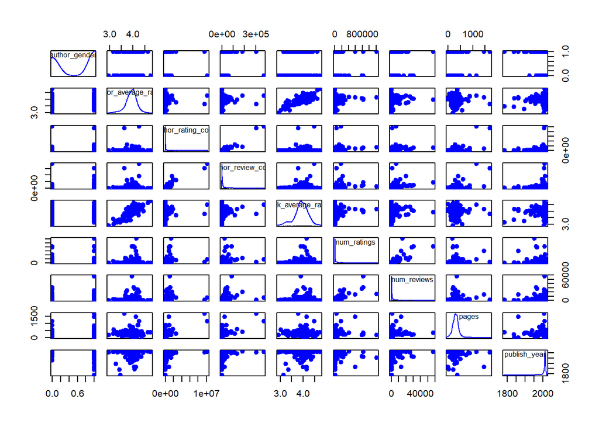

Aunque podemos entrever algunas relaciones básicas (como la alta correlación que existe entre las variables de puntuación del autor y sus obras o entre las variables de los números de reseñas y los números de valoraciones), es difícil extraer resultados con claridad. En la $Figura1$ se encuentra la imagen con mayor detalle.

Veamos la información por separado de las variables relativas al autor y de las variables relativas al libro. Aunque para hacer un estudio más realista sobre los autores deberíamos agrupar los registros por identificador de autor (variable que eliminamos en el preprocesamiento), dejaremos las filas tal y como están, otorgando por tanto un mayor peso lineal a los autores que más obras tengan registradas en la página.

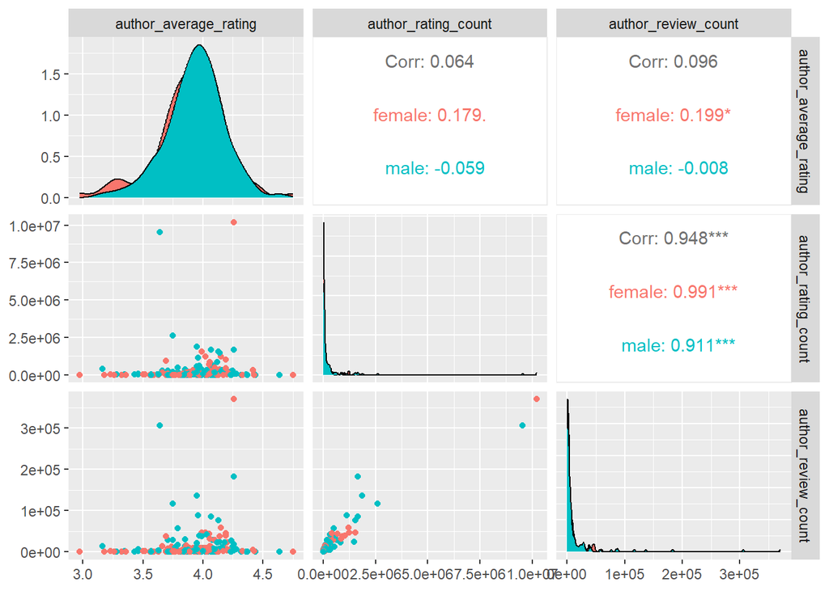

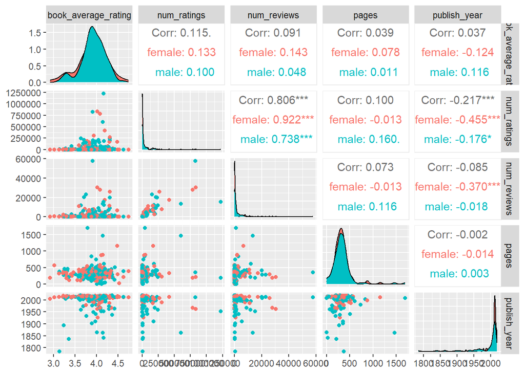

Es posible visualizar estas figuras con más detalle en la $Figura2.1$ y la $Figura2.2$.

##### Histogramas

Pasemos a representar un par de histogramas interesantes. Primero, veamos la distribución del número de páginas.

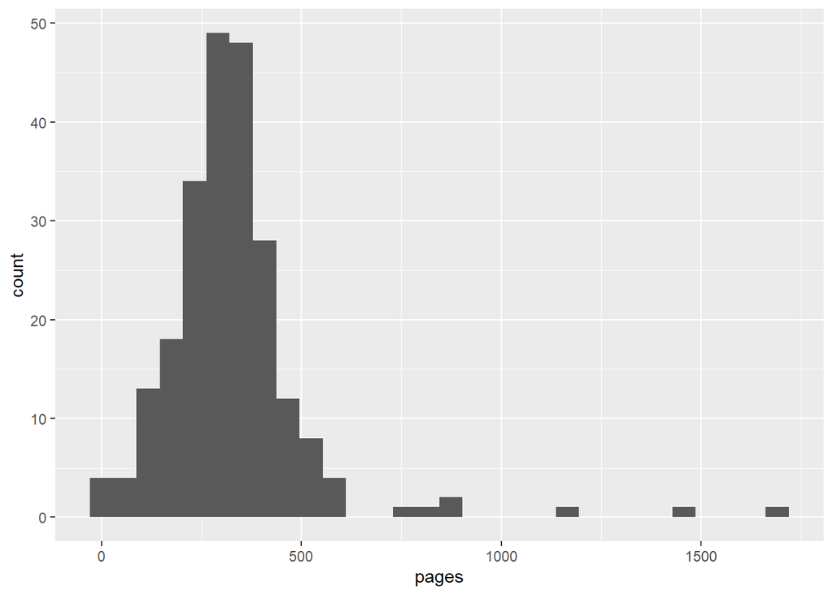

Vemos que la distribución que se sigue es relativamente normal, con la salvedad de la cola que se extiende hacia la derecha.

Veamos ahora los histogramas de evaluaciones (resultados y número) por géneros.

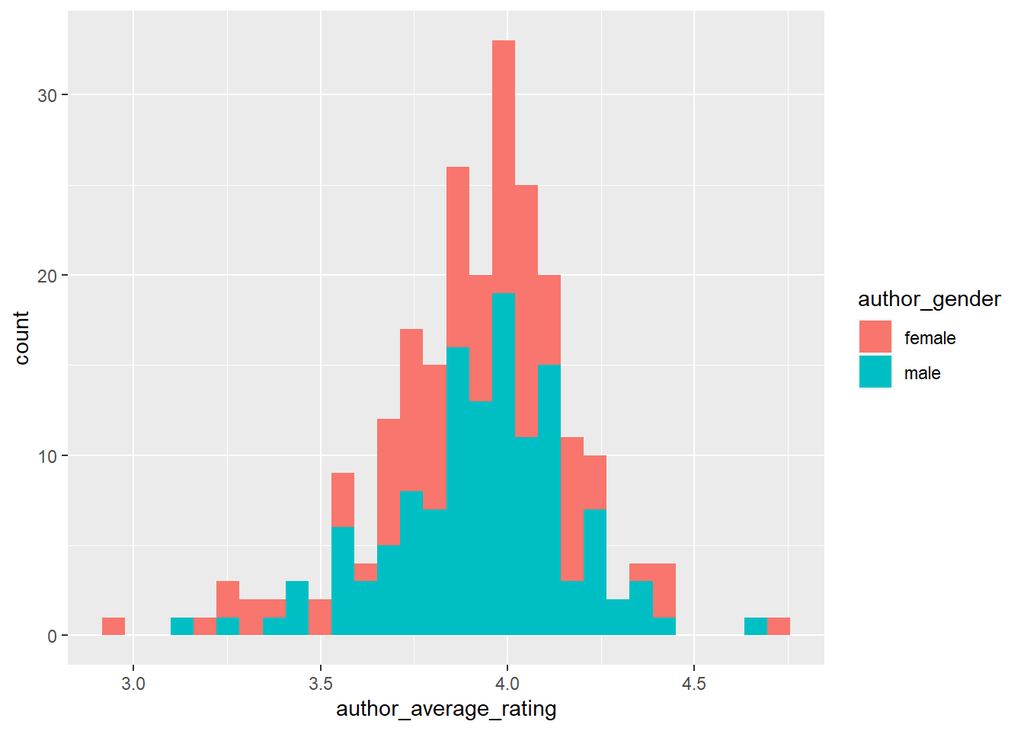

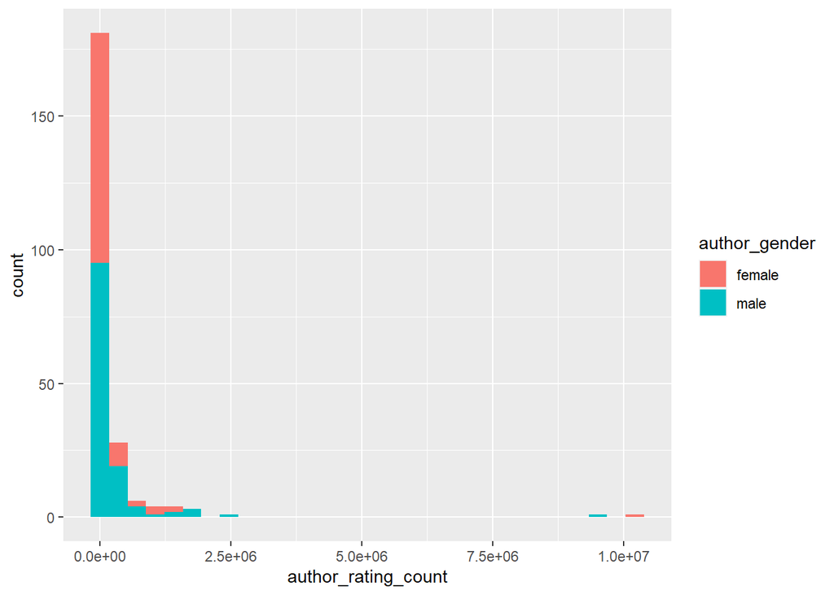

##### Diagramas de cajas

Para poder visualizar cómodamente los datos asociados a los distintos géneros, filtramos primero aquellos géneros (o combinaciones de ellos) más comunes.

```r
good_reads_genres <- good_reads %>% group_by(genre_1,genre_2)
good_reads_genres_count <- good_reads_genres %>% summarise(copies = n())
mostCommonGenres <- head(good_reads_genres_count[order(good_reads_genres_count$copies, decreasing=TRUE),1:2],20)
```

Visualicemos las combinaciones de géneros con más registros en nuestro dataset.

```r
mostCommonGenres
```

```
## # A tibble: 20 × 2
## # Groups:   genre_1 [11]
##    genre_1         genre_2
##    <chr>           <chr>
##  1 Fantasy         Young Adult
##  2 Romance         Romance
##  3 Historical      Fiction
##  4 Fantasy         Fantasy
##  5 Young Adult     Fantasy
##  6 Young Adult     Contemporary
##  7 Classics        Fiction
##  8 Romance         Contemporary
##  9 Fiction         Historical
## 10 Fantasy         Fiction
## 11 Romance         New Adult
## 12 Fantasy         Romance
## 13 Science Fiction Fiction
## 14 Young Adult     Science Fiction
## 15 Young Adult     Romance
## 16 History         Nonfiction
## 17 New Adult       Romance
## 18 Mystery         Fiction
## 19 Fiction         Classics
## 20 Sequential Art  Sequential Art
```

Nos quedamos solo con los registros que tengan estas combinaciones.

Realizamos el mismo proceso para los 5 lugares de nacimiento más comunes con otra copia del DataFrame distinta.

```r
good_reads_birthplace <- good_reads %>% group_by(birthplace)
good_reads_birthplace_count <- good_reads_birthplace %>% summarise(copies = n())

mostCommonBirthplaces <- head(good_reads_birthplace_count[order(good_reads_birthplace_count$copies, decreasing=TRUE),1],5)
```

```r
mostCommonBirthplaces
```

```
## # A tibble: 5 × 1
##   birthplace
##   <chr>
## 1 United States
## 2 United Kingdom
## 3 Canada
## 4 Japan
## 5 Australia
```

Representamos los diagramas de cajas correspondientes a las siguientes relaciones:

- Número de páginas por géneros.

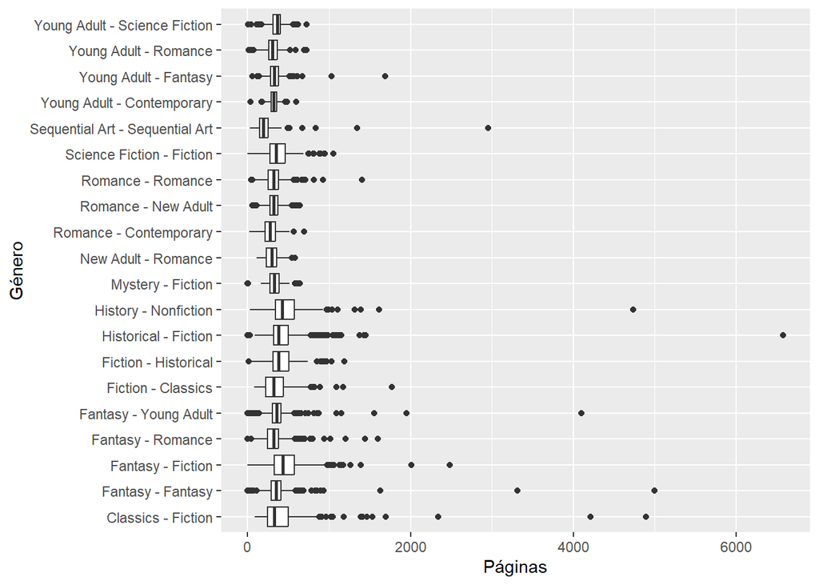

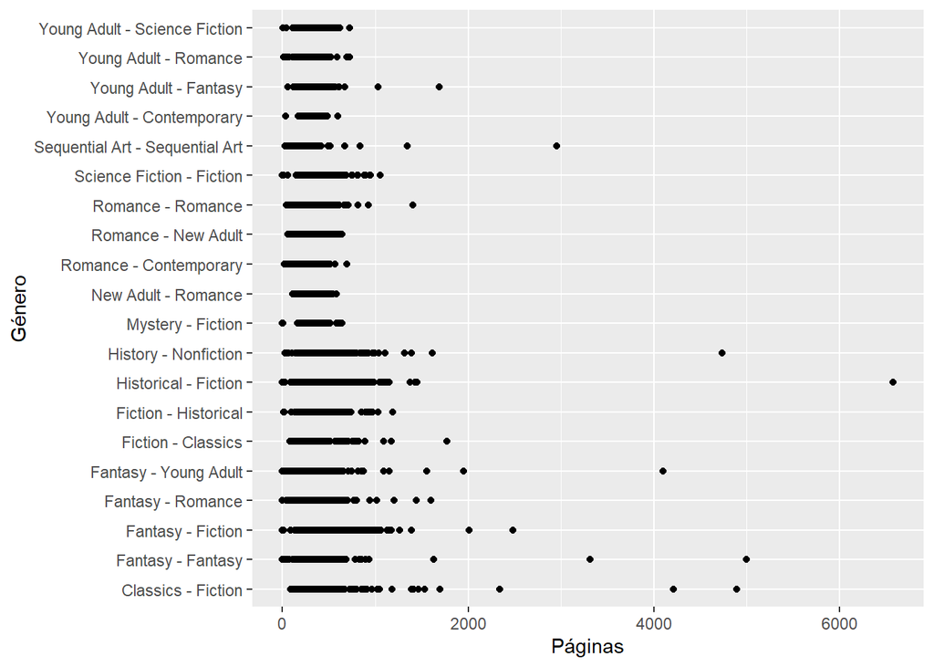

- Como apenas es posible ver nada debido a los outliers, filtramos los datos poniendo un número máximo de páginas para los registros.

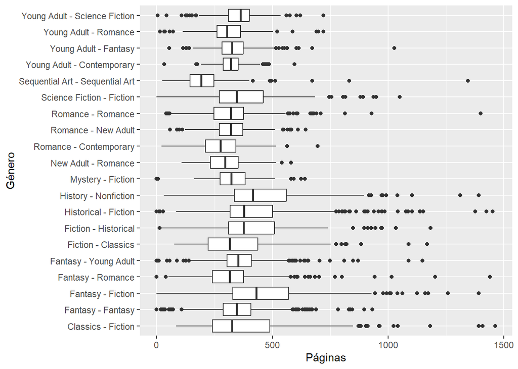

- Número de valoraciones por géneros.

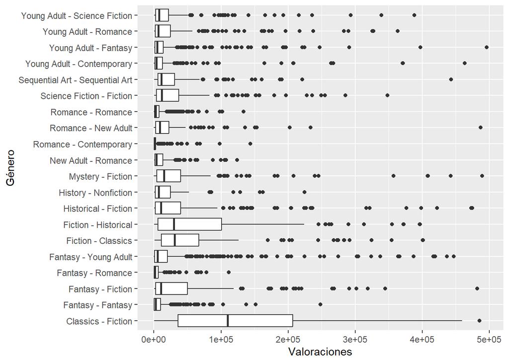

- Puntuaciones medias por géneros.

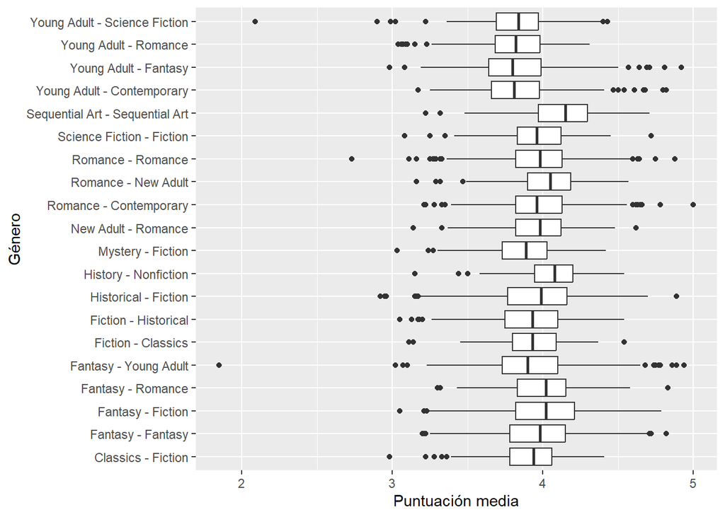

- Puntuaciones medias por lugar de nacimiento.

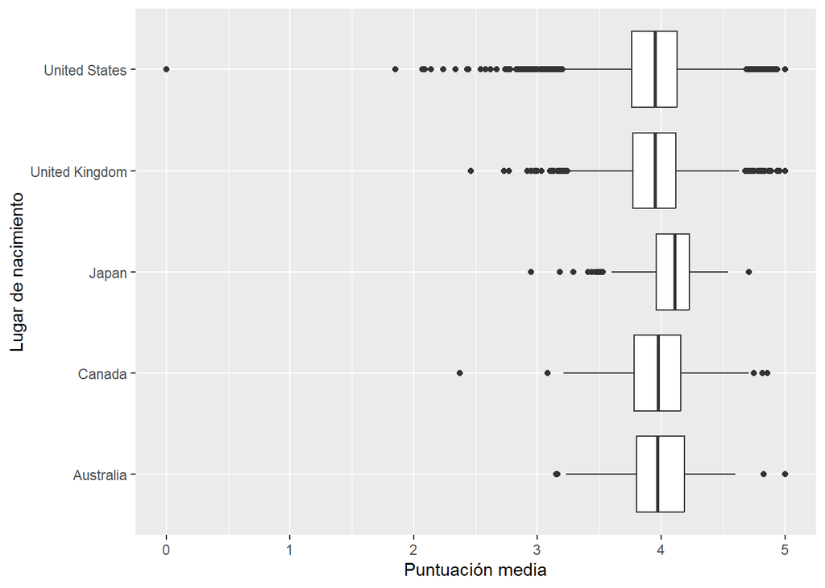

- Fechas de publicación por géneros.

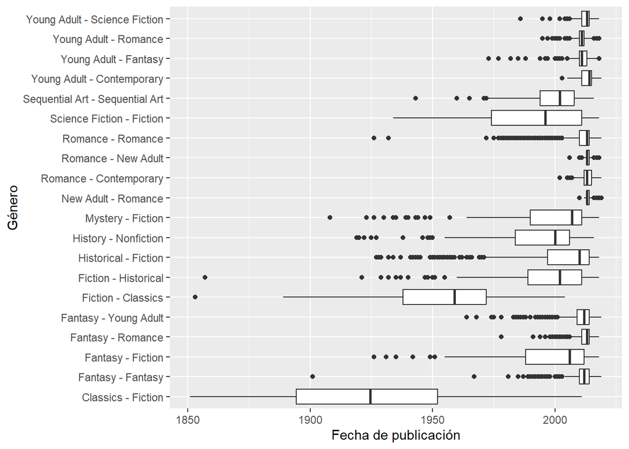

- Fechas de publicación por lugares de nacimiento.

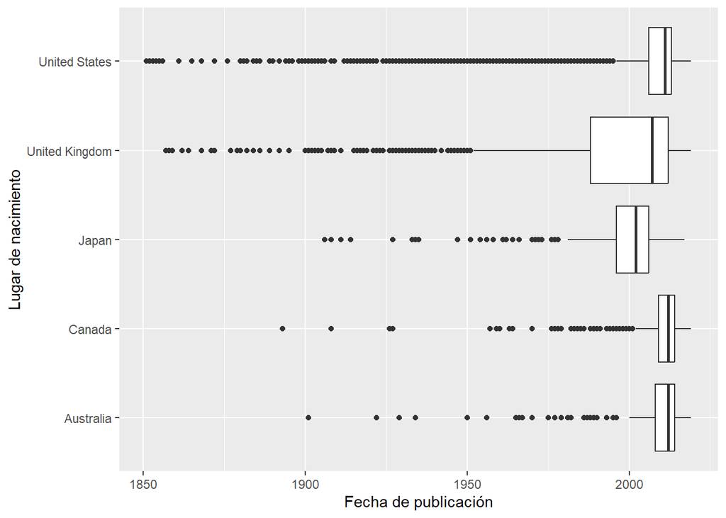

De estas gráficas (que se pueden encontrar con mayor detalle en la $Figura4.1$, $Figura4.2$, $Figura5$, $Figura6$, $Figura7.1$, $Figura8.1$ y $Figura8.2$) se puede extraer información interesante. Por ejemplo:

##### Gráficos de barras

Para poder representar en gráficos de barras la información relativa a las punutaciones de los distintos libros, vamos a dividirla en los tres terciles.

```r
good_reads$rating_range <- ifelse(good_reads$author_average_rating < as.numeric(quantile(good_reads$author_average_rating,0.333)),
                                  'Bajo',
                                  ifelse(good_reads$author_average_rating < as.numeric(quantile(good_reads$author_average_rating,0.666)),
                                         'Medio',
                                         'Alto'))

good_reads$rating_range <- factor(good_reads$rating_range, levels=c('Bajo','Medio','Alto'))
```

Representemos ahora la cantidad de obras publicadas por hombres y mujeres para cada tercil.

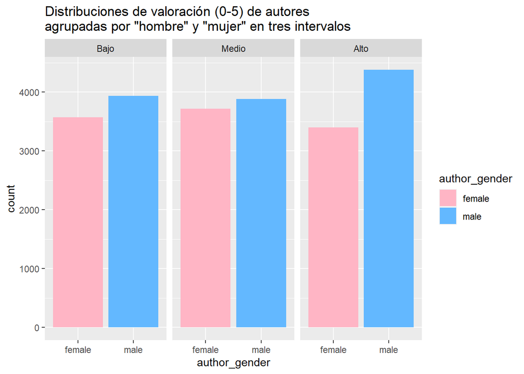

Podemos observar cómo las obras con puntuaciones más extremas suelen ser publicadas por hombres. Particularmente, hay una diferencia bastante grande en las obras del tercer tercil.

Pasemos a estudiar concretamente las obras más extremas; aquellas que se sitúen en el primer y en el último percentil.

```r
good_reads$rating_extreme_range <- ifelse(good_reads$author_average_rating < as.numeric(quantile(good_reads$author_average_rating,0.01)),
                                  'Muy bajo',
                                  ifelse(good_reads$author_average_rating < as.numeric(quantile(good_reads$author_average_rating,0.99)),
                                         'Medio',
                                         'Muy alto'))

good_reads$rating_extreme_range <- factor(good_reads$rating_extreme_range, levels=c('Muy bajo','Medio','Muy alto'))
```

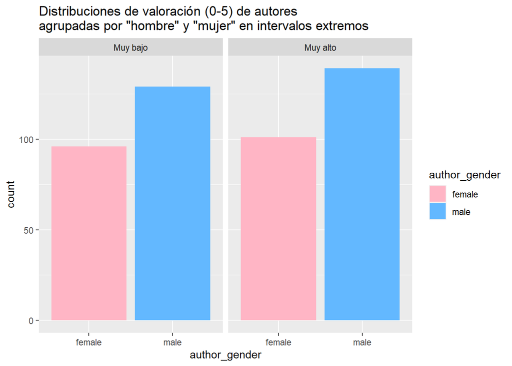

Observamos cómo se cumple lo que comentábamos anteriormente. Los dos últimos gráficos pueden verse con más detalle en la $Figura9.1$ y en la $Figura9.2$.

## 2. Análisis de Componentes Principales (ACP)

En este apartado realizaremos el Análisis de Componentes Principales. Gracias a esta técnica, podremos reducir la dimensión de los datos para poder visualizarlos y manejarlos mejor.

Primero, importaremos nuestros datos de nuevo, de modo que nos sirva este apartado de forma independiente al resto, como si partiéramos de cero.

```r
if(!require(ggplot2)){
  install.packages("ggplot2")
  require(ggplot2)
}
if(!require(dplyr)){
  install.packages("dplyr")
  require(dplyr)
}
```

Importamos los datos.

```r
ruta_read_rda <- "../Datos/Procesados/good_reads_final_preprocesado.rda"
load(file = ruta_read_rda)
head(good_reads, 10)
```

```
##    author_average_rating author_gender                         author_genres
## 1                   4.01        female                    historical-fiction
## 2                   4.15          male literature-fiction, mystery-thrillers
## 3                   4.00        female                               romance
## 4                   3.88          male                       fiction, memoir
## 5                   4.10        female                  young-adult, fantasy
## 6                   3.77          male                                horror
## 7                   4.16        female                               romance
## 8                   3.94        female                            nonfiction
## 9                   3.78        female                               fantasy
## 10                  4.08        female                           young-adult
##    author_rating_count author_review_count    birthplace book_average_rating
## 1                74399                6268 United States                4.02
## 2              3726435              142704        Sweden                4.13
## 3                76496                7975 United States                3.99
```

[output cut: 29 more lines]

Recordemos que teníamos valores nulos en nuestros datos, de modo que hemos de volver a imputarlos.

```r
good_reads$pages[is.na(good_reads$pages)] <- mean(good_reads$pages, na.rm=TRUE)
good_reads$publish_year[is.na(good_reads$publish_year)] <- median(good_reads$publish_year, na.rm=TRUE)
```

Tenemos variables categóricas y numéricas. Para hacer este análisis, vamos a quedarnos con las numéricas y usar el género principal para visualizar mejor los resultados. De entre todos los géneros, nos quedaremos con los cinco más populares.

Nos quedamos con las variables deseadas y las guardamos en un dataframe.

```r
variables_numericas <- c("author_average_rating",
                         "author_rating_count",
                         "author_review_count",
                         "book_average_rating",
                         "num_ratings",
                         "num_reviews",
                         "pages",
                         "publish_year")

good_reads_genres <- good_reads %>% group_by(genre_1)
good_reads_genres_count <- good_reads_genres %>% summarise(copies = n())
mostCommonGenres <- head(good_reads_genres_count[order(good_reads_genres_count$copies, decreasing=TRUE),1:2],5)
good_reads_mostCommonGenres <- filter(good_reads_genres,
                                      any(mostCommonGenres$genre_1 == genre_1))
good_reads_mostCommonGenres$genres <- paste(good_reads_mostCommonGenres$genre_1)
df_pca <- good_reads_mostCommonGenres[,c(variables_numericas, "genres")]
```

Separamos en X e y para el análisis.

```r
X <- as.matrix(df_pca[, -9])
```

Primero, vamos a hacer el Análisis de Componentes Principales de manera “artesanal”, así como vimos en la práctica de la asignatura, por mayor completitud. Para ello, calculamos la matriz de covarianzas.

```r
p <- ncol(X)
S <- cov(X)
```

Calculamos la varianza total.

```r
var_tot <- sum(diag(S))
var_tot
```

```
## [1] 614022404331
```

Calculamos los valores y vectores propios de la matriz de covarianzas.

```r
S_vvprop <- eigen(S)
sum(S_vvprop$values)
```

```
## [1] 614022404331
```

Vemos que se corresponde con la suma de las varianzas de nuestras variables.

```r
100*cumsum(S_vvprop$values)/var_tot
```

```
## [1]  97.14378  99.97033  99.99845  99.99999 100.00000 100.00000 100.00000
## [8] 100.00000
```

Con tan solo las dos primeras componentes llegamos al 99% de varianza acumulada. Aun así, vamos a aplicar el método del codo para comprobarlo.

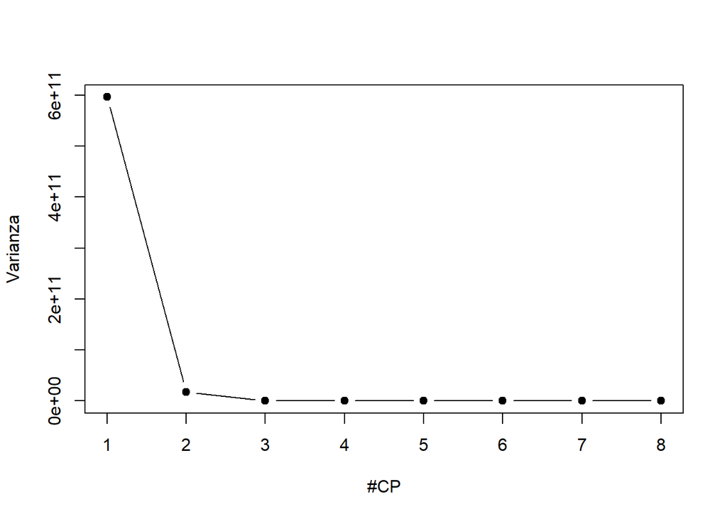

Es evidente que son dos componentes. Aunque con una podríamos obtener buenos resultados, es preferible tener un par de componentes para ayudarnos en la representación.

```r
k <- 2
X_star <- scale(X, scale = FALSE)
```

Calculamos las dos componentes principales y las guardamos en la matriz Y.

```r
Y <- X_star %*% S_vvprop$vectors[, 1:k]
summary(Y)
```

```
##        V1                  V2
##  Min.   :-21046122   Min.   :-2165978
##  1st Qu.:    75616   1st Qu.:   11793
##  Median :   167966   Median :   17704
##  Mean   :        0   Mean   :       0
##  3rd Qu.:   188183   3rd Qu.:   18925
##  Max.   :   192747   Max.   : 2761464
```

```r
head(Y)
```

```
##             [,1]        [,2]
## [1,] -3795925.92 -1704910.46
## [2,]   116403.05    25985.10
## [3,]   187025.53    17097.09
## [4,]   -98286.65    39253.30
## [5,]    81389.62    20959.41
## [6,]  -290059.49    41194.89
```

```r
cov(Y)
```

```
##              [,1]         [,2]
## [1,] 5.964846e+11 7.276679e-06
## [2,] 7.276679e-06 1.735561e+10
```

```r
S_vvprop$vectors[, 1:k]
```

```
##               [,1]          [,2]
## [1,] -3.895267e-08 -3.082703e-08
## [2,] -9.908116e-01  1.313473e-01
## [3,] -3.465768e-02 -1.613930e-02
## [4,] -4.408243e-08 -7.718916e-08
## [5,] -1.306413e-01 -9.902658e-01
## [6,] -4.902196e-03 -4.313966e-02
## [7,] -3.490864e-05  1.073951e-05
## [8,]  1.318461e-06  6.689604e-06
```

Vemos los pesos que tienen cada una de las variables en las 2 componentes. Comprobamos que las que más influyen son el número de reseñas y valoraciones tanto para los libros y los autores.

```r
cor(X, Y)
```

```
##                              [,1]         [,2]
## author_average_rating -0.12875307 -0.017380909
## author_rating_count   -0.99974429  0.022606817
## author_review_count   -0.89856877 -0.071376774
## book_average_rating   -0.11966234 -0.035741166
## num_ratings           -0.61178263 -0.791022337
## num_reviews           -0.48042389 -0.721158975
## pages                 -0.13782723  0.007232808
## publish_year           0.03251064  0.028137073
```

Vamos a mostrar los resultados.

```r
df_pca <- cbind(df_pca, Y)
colnames(df_pca)[10:11] <- paste("CP", 1:k, sep = "")
head(df_pca)
```

```
##   author_average_rating author_rating_count author_review_count
## 1                  4.15             3726435              142704
## 2                  4.00               76496                7975
## 3                  3.88                5522                 489
## 4                  4.10              291013               13453
## 5                  4.16              110522                9451
## 6                  4.08              481114               25166
##   book_average_rating num_ratings num_reviews pages publish_year      genres
## 1                4.13     2229163       65227   465         2005     Fiction
## 2                3.99        2151         391   354         2016     Romance
## 3                4.14        1844         173   438         1970     Fiction
## 4                4.01       17051        1890   326         1988     Fantasy
## 5                3.95       11684        1107   327         2012 Young Adult
## 6                4.01       40093        2375   303         2007 Young Adult
##           CP1         CP2
## 1 -3795925.92 -1704910.46
## 2   116403.05    25985.10
## 3   187025.53    17097.09
## 4   -98286.65    39253.30
## 5    81389.62    20959.41
## 6  -290059.49    41194.89
```

Y vamos visualizando las distintas gráficas.

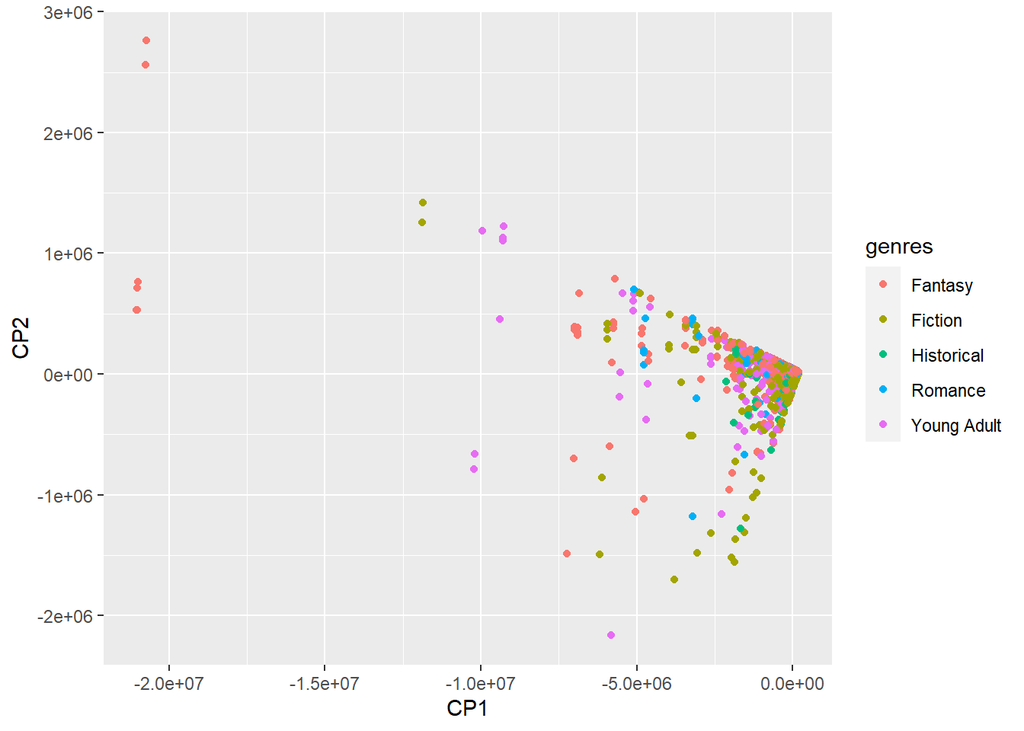

En la primera figura no llegamos a ver nada realmente útil, pero sí que encontramos algunos géneros distanciados del resto. Serán obras muy populares, con muchas reseñas y valoraciones. El resto está aglomerado en un cono y es difícil ver nada. Esto sucede tanto para la primera componente como para la segunda.

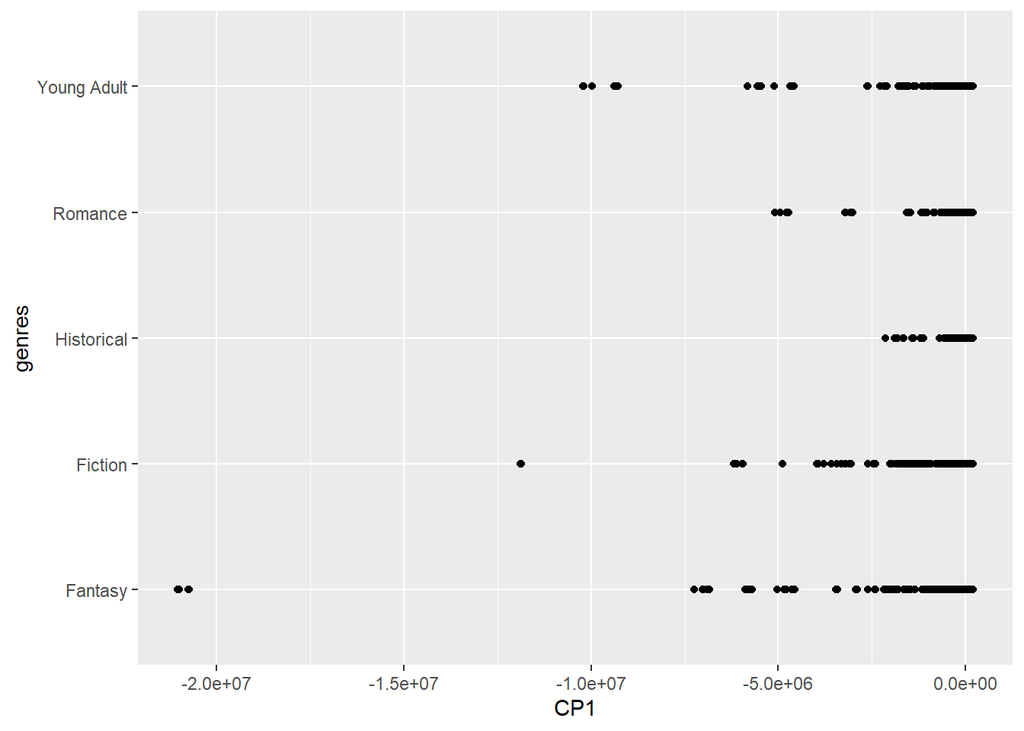

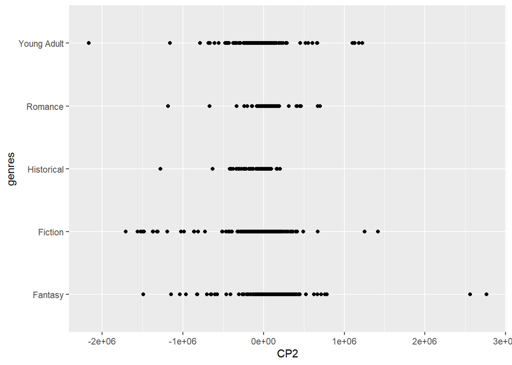

En las otras dos figuras vemos como influyen las distintas componentes a los géneros. Sí que se pueden llegar a apreciar qué géneros (como fantasía, ficción y jóvenes adultos) destacan por tener valores muy alejados del resto, es decir, muy populares. Otros géneros no destacan tanto, como las novelas históricas o el romance contemporáneo.

Las figuras con mejor calidad pueden ser encontradas en la carpeta “./Figuras”, estas son: $Figura10.1$, $Figura10.2$, $Figura10.3$.

Pasamos a usar prcomp que es la librería pensada para hacer estos análisis.

```r
df_acp_cov <- prcomp(X)

df_acp_cov
```

```
## Standard deviations (1, .., p=8):
## [1] 7.723242e+05 1.317407e+05 1.314057e+04 3.079593e+03 1.936181e+02
## [6] 3.122024e+01 3.425789e-01 1.124169e-01
##
## Rotation (n x k) = (8 x 8):
##                                 PC1           PC2           PC3           PC4
## author_average_rating -3.895267e-08 -3.082703e-08 -1.810137e-06 -2.283774e-06
## author_rating_count   -9.908116e-01  1.313473e-01  3.148673e-02  6.986003e-03
## author_review_count   -3.465768e-02 -1.613930e-02 -9.805061e-01 -1.927335e-01
## book_average_rating   -4.408243e-08 -7.718916e-08 -1.748357e-06 -1.617061e-06
## num_ratings           -1.306413e-01 -9.902658e-01  2.851393e-02 -3.864481e-02
## num_reviews           -4.902196e-03 -4.313966e-02 -1.918419e-01  9.804629e-01
## pages                 -3.490864e-05  1.073951e-05 -2.472922e-04  1.993271e-03
## publish_year           1.318461e-06  6.689604e-06 -1.431577e-04  2.180539e-04
##                                 PC5           PC6           PC7           PC8
## author_average_rating -1.205872e-04 -4.901330e-05 -6.170549e-01 -7.869201e-01
## author_rating_count    4.214976e-05 -3.252212e-06 -5.972836e-08 -8.224088e-09
## author_review_count   -1.410326e-04  9.765323e-05  3.002281e-06  4.784554e-07
## book_average_rating   -2.091365e-04  9.335545e-05 -7.869200e-01  6.170549e-01
## num_ratings           -9.008165e-05 -1.964691e-05  1.398935e-07 -2.844878e-09
## num_reviews            2.000553e-03  2.485459e-04 -2.614727e-06 -6.739783e-07
## pages                 -9.999908e-01 -3.789349e-03  2.388119e-04 -3.379300e-05
## publish_year           3.789813e-03 -9.999928e-01 -4.412500e-05  9.630361e-05
```

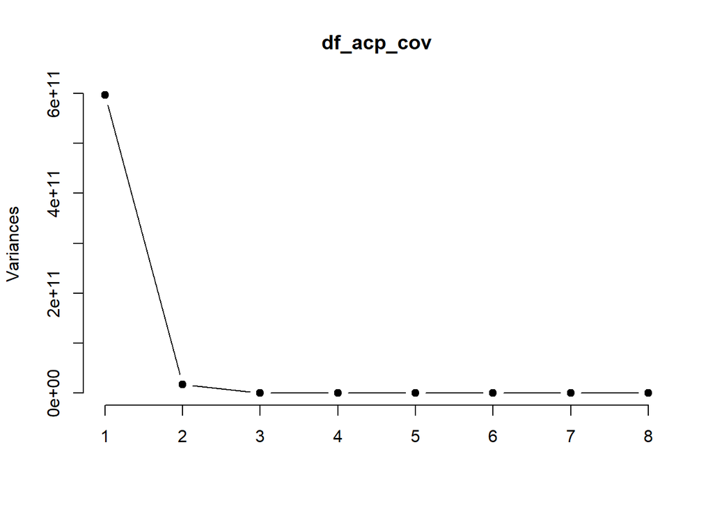

De nuevo, parece conveniente quedarse con k = 2.

```r
cov(df_acp_cov$x[, 1:2])
```

```
##               PC1           PC2
## PC1  5.964846e+11 -6.958479e-05
## PC2 -6.958479e-05  1.735561e+10
```

```r
df_acp_cov$rotation[, 1:2]
```

```
##                                 PC1           PC2
## author_average_rating -3.895267e-08 -3.082703e-08
## author_rating_count   -9.908116e-01  1.313473e-01
## author_review_count   -3.465768e-02 -1.613930e-02
## book_average_rating   -4.408243e-08 -7.718916e-08
## num_ratings           -1.306413e-01 -9.902658e-01
## num_reviews           -4.902196e-03 -4.313966e-02
## pages                 -3.490864e-05  1.073951e-05
## publish_year           1.318461e-06  6.689604e-06
```

Vemos qué características influyen más en cada componente. En general, las variables del número de valoraciones parecen tener mayor peso que las demás. Recuperamos el dataset original y le añadimos las dos componentes.

```r
df_pca <-
df_pca <- cbind(df_pca, df_acp_cov$x[, 1:2])
```

Hecho esto, vamos a visualizar los resultados.

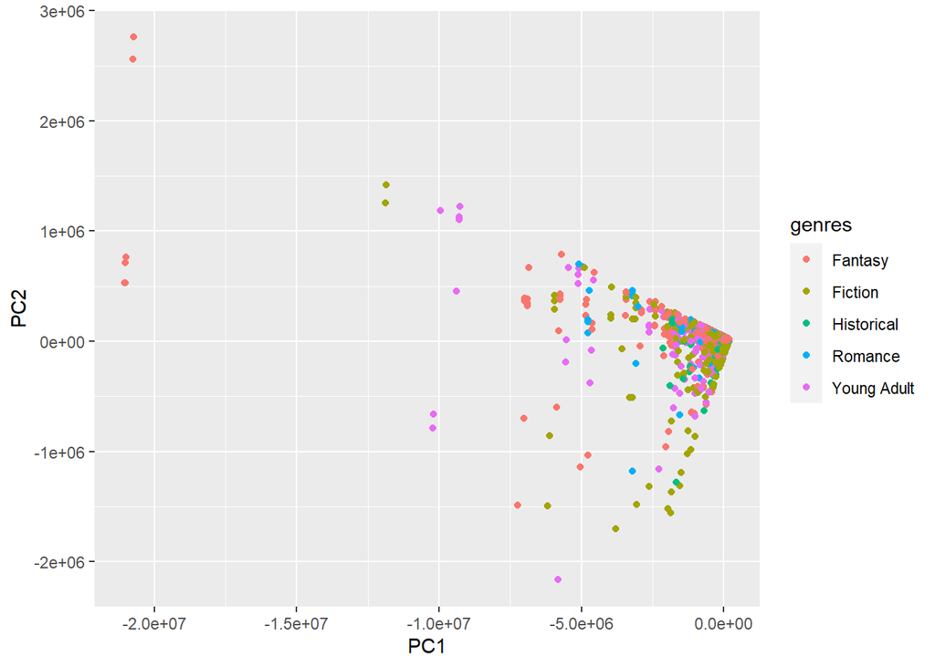

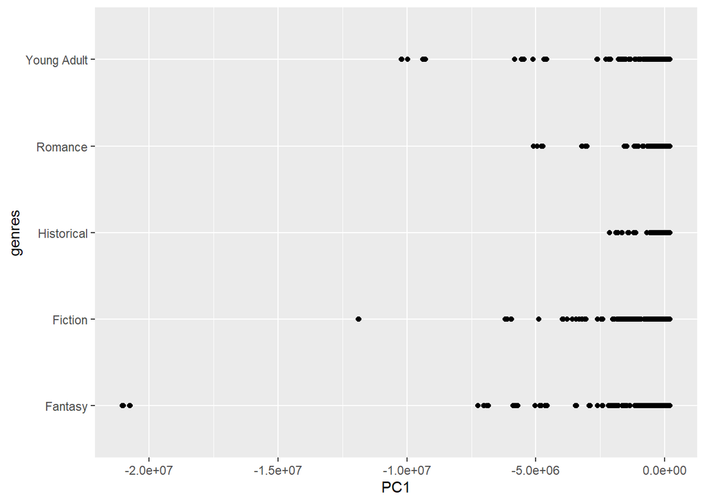

Vemos que los gráficos generados son prácticamente idénticos a los obtenidos por el método artesanal. En el primero concretamente parece ser posible apreciar una división en grupos por medio del eje de la primera componente.

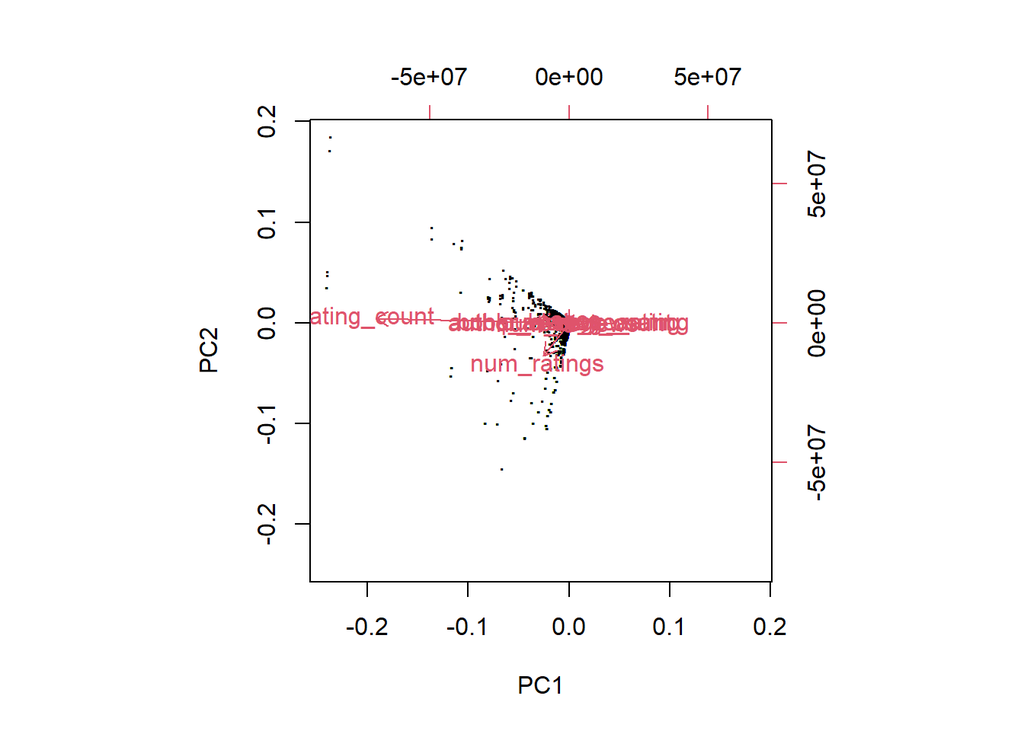

En esta gráfica, lo relevante son los ejes y las flechas más que las observaciones, y es que solo dos variables tienen relevancia: “rating_count” para PC1 y “num_ratings” para PC2.

Mayor detalle de estas tres figuras en $Figura10.4$, $Figura10.5$ y $Figura10.6$.

Por terminar con este apartado, vamos a utilizar la matriz de correlaciones y no la de covarianzas para realizar el análisis.

```r
df_acp_corr <- prcomp(X, scale. = TRUE)
df_acp_corr
```

```
## Standard deviations (1, .., p=8):
## [1] 1.7714341 1.3209395 1.0040453 0.9739198 0.8593931 0.4423141 0.4242731
## [8] 0.2151912
##
## Rotation (n x k) = (8 x 8):
##                               PC1          PC2         PC3         PC4
## author_average_rating -0.18280130  0.664921161 -0.07171959  0.15254263
## author_rating_count   -0.47273696 -0.113033882  0.01955688 -0.08725623
## author_review_count   -0.50049341 -0.105559946 -0.02468369 -0.05608892
## book_average_rating   -0.18286949  0.669448891 -0.03329566  0.11834569
## num_ratings           -0.48082725 -0.172810419 -0.02192959  0.12572430
## num_reviews           -0.46180956 -0.162472851 -0.06169581  0.12531284
## pages                 -0.11927291  0.171831621  0.34297176 -0.89126996
## publish_year           0.02189997  0.003390913 -0.93318757 -0.35509630
##                               PC5         PC6         PC7          PC8
## author_average_rating -0.01364108  0.67290627 -0.20679909 -0.017198452
## author_rating_count   -0.55866563 -0.12491617 -0.33982550 -0.559065546
## author_review_count   -0.42518943  0.12808992  0.46811586  0.564165458
## book_average_rating    0.03708713 -0.68372382  0.18553238  0.002578273
## num_ratings            0.41909902 -0.15648106 -0.60054374  0.402332102
## num_reviews            0.53513740  0.14555103  0.47579128 -0.454851991
## pages                  0.20647944  0.03714885 -0.01202010  0.009890628
## publish_year           0.02992238 -0.02561923 -0.03199125 -0.001157272
```

```r
summary(df_acp_corr)
```

```
## Importance of components:
##                           PC1    PC2    PC3    PC4     PC5     PC6    PC7
## Standard deviation     1.7714 1.3209 1.0040 0.9739 0.85939 0.44231 0.4243
## Proportion of Variance 0.3922 0.2181 0.1260 0.1186 0.09232 0.02446 0.0225
## Cumulative Proportion  0.3922 0.6104 0.7364 0.8549 0.94726 0.97171 0.9942
##                            PC8
## Standard deviation     0.21519
## Proportion of Variance 0.00579
## Cumulative Proportion  1.00000
```

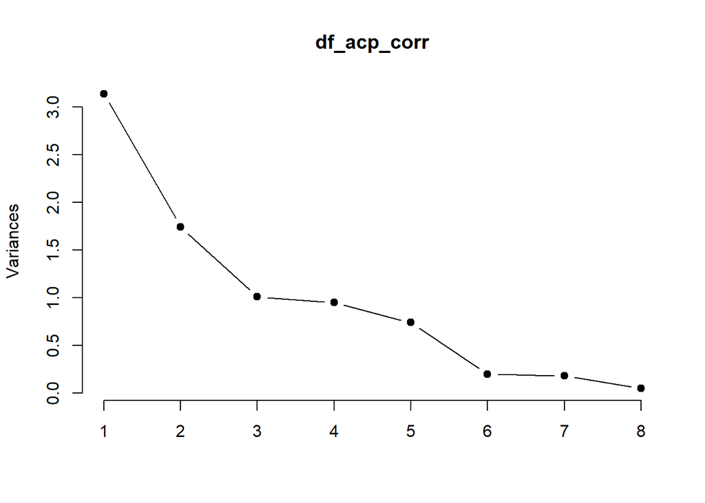

```r
plot(df_acp_corr, type = "l", pch = 19)
```

Aquí parece ser más complicado decidirse, y podría paracer que lo mejor es k=5. Para poder visualizar los resultados de forma sencilla, consideraremos k = 2.

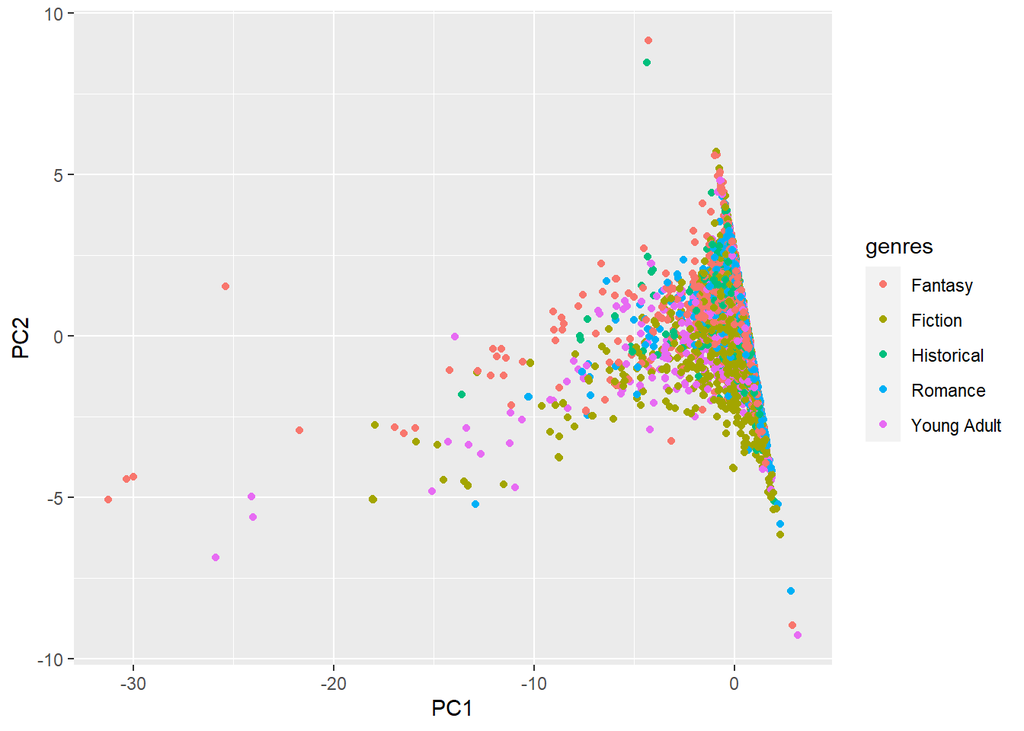

```r
df_pca <- good_reads_mostCommonGenres[,c(variables_numericas, "genres")]
df_pca <- cbind(df_pca, df_acp_corr$x[, 1:2])
ggplot(df_pca, aes(x = PC1, y = PC2, color = genres, fill = genres)) +
  geom_point()
```

Realmente no se puede sacar demasiado en claro de esta gráfica, se nota que nuestras variables numéricas no pueden ser negativas y son cortadas en ese eje. No obstante, se pueden apreciar las tendencias de los géneros: pocos puntos veres o azules (historicos y romance en ese orden) se llegan a distanciar del conglomerado, mientras que hay aglomeraciones estiradas paralelas de géneros destacados, como fantasía o ficción.

Figura con mayor detalle en $Figura10.7$.

## 3. Análisis Factorial (AF)

Volvemos a ejecutar la importación de paquetes y de los datos.

```r
if(!require(psych)){
  install.packages("psych")
  require(psych)
}

if(!require(ggplot2)){
  install.packages("ggplot2")
  require(ggplot2)
}
```

```r
ruta_read_rda <- "../Datos/Procesados/good_reads_final_preprocesado.rda"
load(file = ruta_read_rda)
```

Tratamos de nuevo los valores nulos.

```r
apply(good_reads, 2, function(x) return(sum(is.na(x))))
```

```
## author_average_rating         author_gender         author_genres
##                     0                     0                     0
##   author_rating_count   author_review_count            birthplace
##                     0                     0                  4449
##   book_average_rating               genre_1               genre_2
##                     0                     0                     0
##           num_ratings           num_reviews                 pages
##                     0                     0                     3
##                 score          publish_year
##                     0                   743
```

```r
good_reads$pages[is.na(good_reads$pages)] <- mean(good_reads$pages, na.rm=TRUE)
good_reads$publish_year[is.na(good_reads$publish_year)] <- median(good_reads$publish_year, na.rm=TRUE)
```

Volvemos a realizar la selección de variables numéricas.

```r
variables_numericas <- c("author_average_rating",
                         "author_rating_count",
                         "author_review_count",
                         "book_average_rating",
                         "num_ratings",
                         "num_reviews",
                         "pages",
                         "publish_year")

X <- good_reads[variables_numericas]
```

Vamos a comenzar realizando un Análisis Factorial “Artesanal”. Conseguimos el número de variables y la matriz de correlaciones de nuestros datos.

```r
p <- ncol(X)
R <- cor(X)
R
```

```
##                       author_average_rating author_rating_count
## author_average_rating           1.000000000          0.08878947
## author_rating_count             0.088789465          1.00000000
## author_review_count             0.101794142          0.89766539
## book_average_rating             0.812691977          0.08617444
## num_ratings                     0.059084337          0.56601155
## num_reviews                     0.060119488          0.48397366
## pages                           0.058687964          0.09939858
## publish_year                   -0.008433005         -0.02533822
##                       author_review_count book_average_rating num_ratings
## author_average_rating         0.101794142          0.81269198  0.05908434
## author_rating_count           0.897665386          0.08617444  0.56601155
## author_review_count           1.000000000          0.09468459  0.51766998
## book_average_rating           0.094684588          1.00000000  0.06644504
## num_ratings                   0.517669980          0.06644504  1.00000000
## num_reviews                   0.598060311          0.06659113  0.82894492
## pages                         0.101159872          0.11231913  0.04086913
## publish_year                  0.006157746         -0.01455290 -0.05661455
##                       num_reviews       pages publish_year
## author_average_rating  0.06011949  0.05868796 -0.008433005
## author_rating_count    0.48397366  0.09939858 -0.025338217
## author_review_count    0.59806031  0.10115987  0.006157746
## book_average_rating    0.06659113  0.11231913 -0.014552905
## num_ratings            0.82894492  0.04086913 -0.056614554
## num_reviews            1.00000000  0.05801204 -0.015235747
## pages                  0.05801204  1.00000000 -0.036787458
## publish_year          -0.01523575 -0.03678746  1.000000000
```

Calculamos los valores y vectores propios.

```r
Rprop <- eigen(R)
Rprop
```

```
## eigen() decomposition
## $values
## [1] 3.00435164 1.78337705 1.02217250 0.96878278 0.76576972 0.22257614 0.18520800
## [8] 0.04776218
##
## $vectors
##             [,1]        [,2]         [,3]        [,4]         [,5]        [,6]
## [1,] -0.13366693 -0.68561392 -0.083970104 -0.09582424 -0.008255173  0.04023962
## [2,] -0.49300660  0.08275916 -0.005524066  0.10163515 -0.510954506 -0.37614263
## [3,] -0.50463374  0.07869578 -0.038931004  0.11479499 -0.452652973  0.39845033
## [4,] -0.13596771 -0.68896828 -0.041689972 -0.05071497  0.029803514 -0.04527856
## [5,] -0.47841301  0.12094845 -0.015195312 -0.17075594  0.470419837 -0.60438032
## [6,] -0.47866507  0.11925644 -0.046677570 -0.12402945  0.495579337  0.57288684
## [7,] -0.08551787 -0.11492747  0.567374815  0.77964936  0.216983813 -0.01355866
## [8,]  0.02495290  0.01245809 -0.815684348  0.55887752  0.138198063 -0.04925381
##               [,7]         [,8]
## [1,]  7.028551e-01 -0.011866980
## [2,]  5.897070e-03 -0.580639845
## [3,] -2.620130e-02  0.600095288
## [4,] -7.067991e-01  0.004693664
## [5,]  4.830647e-02  0.371752706
## [6,] -3.100880e-02 -0.405383511
## [7,]  4.912654e-02  0.005641999
## [8,]  2.652123e-05 -0.003530140
```

```r
Rprop$vectors %*% diag(Rprop$values) %*% t(Rprop$vectors)
```

```
##              [,1]        [,2]        [,3]        [,4]        [,5]        [,6]
## [1,]  1.000000000  0.08878947 0.101794142  0.81269198  0.05908434  0.06011949
## [2,]  0.088789465  1.00000000 0.897665386  0.08617444  0.56601155  0.48397366
## [3,]  0.101794142  0.89766539 1.000000000  0.09468459  0.51766998  0.59806031
## [4,]  0.812691977  0.08617444 0.094684588  1.00000000  0.06644504  0.06659113
## [5,]  0.059084337  0.56601155 0.517669980  0.06644504  1.00000000  0.82894492
## [6,]  0.060119488  0.48397366 0.598060311  0.06659113  0.82894492  1.00000000
## [7,]  0.058687964  0.09939858 0.101159872  0.11231913  0.04086913  0.05801204
## [8,] -0.008433005 -0.02533822 0.006157746 -0.01455290 -0.05661455 -0.01523575
##             [,7]         [,8]
## [1,]  0.05868796 -0.008433005
## [2,]  0.09939858 -0.025338217
## [3,]  0.10115987  0.006157746
## [4,]  0.11231913 -0.014552905
## [5,]  0.04086913 -0.056614554
## [6,]  0.05801204 -0.015235747
## [7,]  1.00000000 -0.036787458
## [8,] -0.03678746  1.000000000
```

Hallamos los porcentajes acumulados de varianza.

```r
cumvar <- 100*cumsum(Rprop$values)/p
```

Utilizamos el método del codo para decidir con cuántos factores nos quedamos.

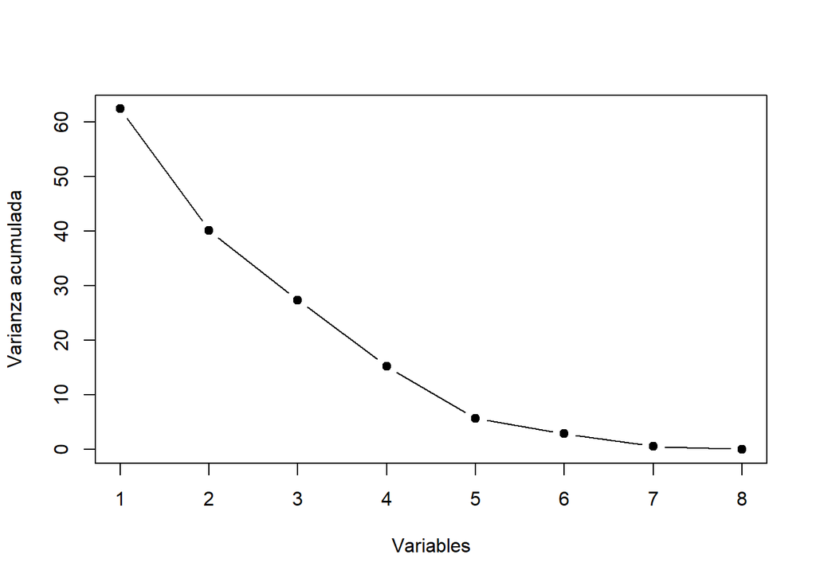

Elegimos 2 factores, y obtenemos la estimación de la matriz de cargas.

```r
m <- 2
sum(Rprop$values[(m + 1):p]) # cota de la suma de cuadrados de la matriz residual
```

```
## [1] 3.212271
```

```r
L <- (rep(1, p) %*% t(sqrt(Rprop$values[1:m]))) * Rprop$vectors[, 1:m]
rownames(L) <- colnames(X)
L
```

```
##                              [,1]        [,2]
## author_average_rating -0.23168577 -0.91559036
## author_rating_count   -0.85453158  0.11051919
## author_review_count   -0.87468498  0.10509282
## book_average_rating   -0.23567372 -0.92006988
## num_ratings           -0.82923640  0.16151836
## num_reviews           -0.82967331  0.15925880
## pages                 -0.14822868 -0.15347775
## publish_year           0.04325102  0.01663692
```

La primera variable habla de la popularidad y la segunda del nivel de calidad. Con la primera, vemos que todas las variables relevantes son el número de reseñas y valoraciones, tanto para el autor como para la propia obra. Con la segunda, vemos que las dos variables más importantes hacen referencia a la puntuación media, tanto del autor como de la obra.

Comunalidades:

```
## author_average_rating   author_rating_count   author_review_count
##           0.891984007           0.742438709           0.776118317
##   book_average_rating           num_ratings           num_reviews
##           0.902070696           0.713721191           0.713721169
##                 pages          publish_year
##           0.045527161           0.002147438
```

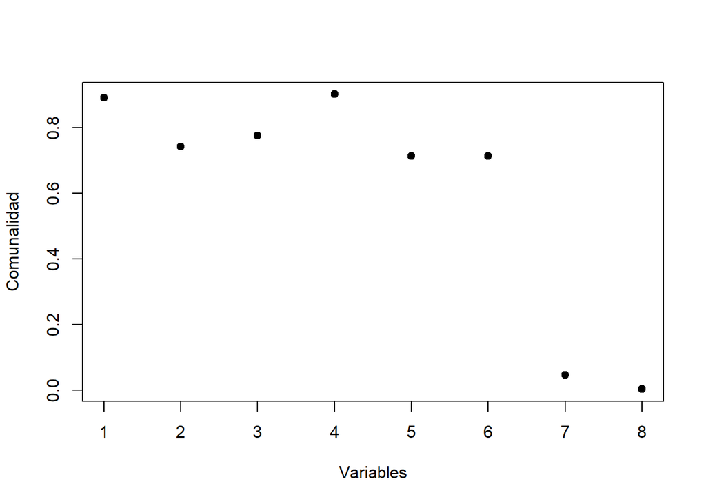

Vemos que las dos últimas variables, “pages” y “publish_year”, tienen una comunalidad prácticamente nula. El resto de variables tienen la comunalidad bastante alta, siendo las que más tienen “author_average_rating” y “book_average_rating”.

Unicidades:

```r
psi <- 1 - h2
psi
```

```
## author_average_rating   author_rating_count   author_review_count
##             0.1080160             0.2575613             0.2238817
##   book_average_rating           num_ratings           num_reviews
##             0.0979293             0.2862788             0.2862788
##                 pages          publish_year
##             0.9544728             0.9978526
```

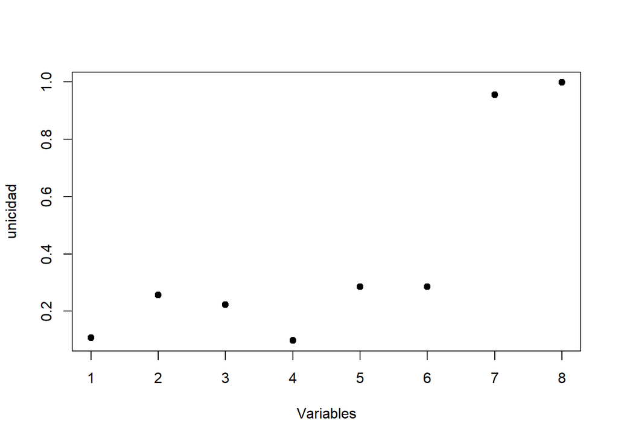

El modelo está bien ajustado, aunque dos variables se quedan bastante fuera. Recordemos que debemos tener un equilibrio entre tener poca unicidad y pocos factores. Lo ideal sería ver qué pasa si añadimos un tercer factor, pero eso es mejor que lo probemos cuando usemos la función “principal”.

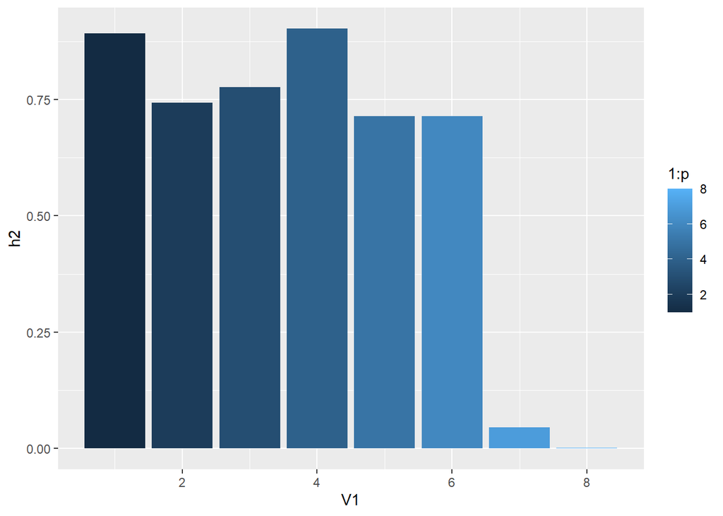

En este diagrama de barras podemos ver las seis variables con alta comunialidad y las dos variables con baja comunalidad.

Hallamos la estimación de la matriz de correlaciones para posteriormente calcular los residuos.

```r
Rbarra <- L %*% t(L) + diag(psi)
Rbarra
```

```
##                       author_average_rating author_rating_count
## author_average_rating            1.00000000          0.09679250
## author_rating_count              0.09679250          1.00000000
## author_review_count              0.10643009          0.75906071
## book_average_rating              0.89700937          0.09970526
## num_ratings                      0.04423762          0.72645957
## num_reviews                      0.04640768          0.72658320
## pages                            0.17486522          0.10970385
## publish_year                    -0.02525325         -0.03512067
##                       author_review_count book_average_rating num_ratings
## author_average_rating           0.1064301          0.89700937  0.04423762
## author_rating_count             0.7590607          0.09970526  0.72645957
## author_review_count             1.0000000          0.10944753  0.74229505
## book_average_rating             0.1094475          1.00000000  0.04682105
## num_ratings                     0.7422950          0.04682105  1.00000000
## num_reviews                     0.7424397          0.04900298  0.71371853
## pages                           0.1135240          0.17614386  0.09812714
## publish_year                   -0.0360826         -0.02550026 -0.03317816
##                       num_reviews        pages publish_year
## author_average_rating  0.04640768  0.174865224 -0.025253252
## author_rating_count    0.72658320  0.109703851 -0.035120667
## author_review_count    0.74243974  0.113523990 -0.036082600
## book_average_rating    0.04900298  0.176143860 -0.025500260
## num_ratings            0.71371853  0.098127142 -0.033178155
## num_reviews            1.00000000  0.098538697 -0.033234644
## pages                  0.09853870  1.000000000 -0.008964439
## publish_year          -0.03323464 -0.008964439  1.000000000
```

Calculamos la matriz residual y a partir de ella su suma de cuadrados para tener una medida de calidad de ajuste.

```r
D <- R - Rbarra
sum(D^2)
```

```
## [1] 0.4475456
```

```r
sum(D^2) <= sum(Rprop$values[3:p])
```

```
## [1] TRUE
```

Ahora vamos a mostrar gráficamente las distintas cargas en el espacio de los factores.

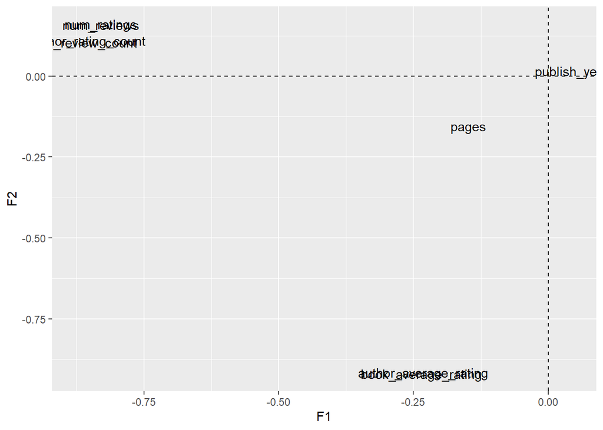

Vemos que hay dos variables que se quedan en tierra de nadie, tanto “publish_year” como “pages”. También vemos que las variables que comentábamos anteriormente son las que determinan cada uno de los factores, dándonos información sobre popularidad (F1) y sobre nivel de calidad (F2).

Aplicamos la rotación para maximizar la varianza total.

```r
vmax_L <- varimax(as.matrix(L))
```

Comprobamos los valores rotados.

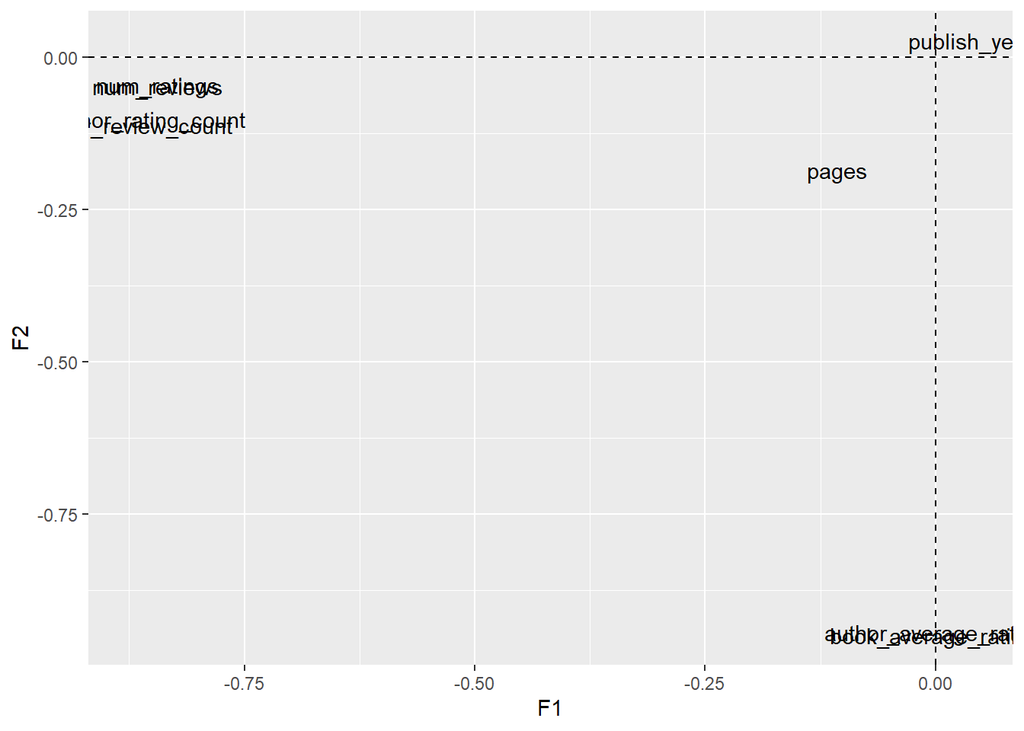

Vemos que las cargas se han ajustado aún más a los ejes de cada factor, y nuestras variables con alta unicidad poco siguen aportando.